# R : Exploring Penalized Models for Handling High-Dimensional Survival Data

John Pauline Pineda

June 30, 2023

# **1. Table of Contents**

## 1.1 Sample Data

The **peakVO2** dataset from the **randomForestSRC** package was used for this illustrated example.  
Preliminary dataset assessment:  
**[A]** 2231 rows (observations)  
**[B]** 41 columns (variables)  
**[B.1]** 1/41 survival event status = died variable (factor)  
**[B.1.1]** Event = died=1  
**[B.1.2]** Censored or Non-Event = died=0  
**[B.2]** 1/41 survival time = ttodead variable (numeric)  
**[B.3]** 39/41 predictors = All remaining variables (26/39 factor + 13/39 numeric)

**Code Chunk | Output**

```r
##################################
# Loading R libraries
##################################
library(survival)
library(survminer)
library(mice)
library(foreign)
library(rms)
library(Hmisc)
library(VIM)
library(gridExtra)
library(finalfit)
library(knitr)
library(dplyr)
library(gtsummary)
library(tidyr)
library(purrr)
library(moments)
library(skimr)
library(caret)
library(corrplot)
library(randomForestSRC)
library(SurvMetrics)
library(pec)
library(hdnom)

##################################
# Loading source and
# formulating the train set
##################################
data(peakVO2)
peakVO2 <- as.data.frame(peakVO2)

##################################
# Converting survival time
# to discrete monthly data
##################################
peakVO2$ttodead <- ceiling(peakVO2$ttodead*12)
peakVO2.Source <- peakVO2

##################################
# Setting the appropriate data types
# for exploratory data analysis
##################################
peakVO2.Assessment <- (as.data.frame(sapply(peakVO2, function(x) max(x))))
names(peakVO2.Assessment) <- c("Max.Value")
peakVO2.Assessment$Variables <- rownames(peakVO2.Assessment)
peakVO2.Assessment
```

```
##                          Max.Value               Variables
## age                       82.00000                     age
## betablok                   1.00000                betablok
## dilver                     1.00000                  dilver
## nifed                      1.00000                   nifed
## acei                       1.00000                    acei
## angioten.II                1.00000             angioten.II
## anti.arrhy                 1.00000              anti.arrhy
## anti.coag                  1.00000               anti.coag
## aspirin                    1.00000                 aspirin
## digoxin                    1.00000                 digoxin
## nitrates                   1.00000                nitrates
## vasodilator                1.00000             vasodilator
## diuretic.loop              1.00000           diuretic.loop
## diuretic.thiazide          1.00000       diuretic.thiazide
## diuretic.potassium.spar    1.00000 diuretic.potassium.spar
## lipidrx.statin             1.00000          lipidrx.statin
## insulin                    1.00000                 insulin
## surgery.pacemaker          1.00000       surgery.pacemaker
## surgery.cabg               1.00000            surgery.cabg
## surgery.pci                1.00000             surgery.pci
## surgery.aicd.implant       1.00000    surgery.aicd.implant
## resting.systolic.bp      184.00000     resting.systolic.bp
## resting.hr               124.00000              resting.hr
## smknow                     1.00000                  smknow
## q.wave.mi                  1.00000               q.wave.mi
## bmi                       59.61593                     bmi
## niddm                      1.00000                   niddm
## lvef.metabl               40.00000             lvef.metabl
## peak.rer                   1.80000                peak.rer
## peak.vo2                  43.80000                peak.vo2
## interval                1415.00000                interval
## cad                        1.00000                     cad
## died                       1.00000                    died
## ttodead                  127.00000                 ttodead
## bun                      129.00000                     bun
## sodium                   152.00000                  sodium
## hgb                       19.20000                     hgb
## glucose                  424.00000                 glucose
## male                       1.00000                    male
## black                      1.00000                   black
## crcl                     385.84097                    crcl
```

```r
(peakVO2.FactorNames <- peakVO2.Assessment[peakVO2.Assessment[,1]==1,2])
```

```
##  [1] "betablok"                "dilver"
##  [3] "nifed"                   "acei"
##  [5] "angioten.II"             "anti.arrhy"
##  [7] "anti.coag"               "aspirin"
##  [9] "digoxin"                 "nitrates"
## [11] "vasodilator"             "diuretic.loop"
## [13] "diuretic.thiazide"       "diuretic.potassium.spar"
## [15] "lipidrx.statin"          "insulin"
## [17] "surgery.pacemaker"       "surgery.cabg"
## [19] "surgery.pci"             "surgery.aicd.implant"
## [21] "smknow"                  "q.wave.mi"
## [23] "niddm"                   "cad"
## [25] "died"                    "male"
## [27] "black"
```

```r
peakVO2.Factor <- peakVO2[,peakVO2.FactorNames]
peakVO2.Factor <- as.data.frame(lapply(peakVO2.Factor, factor))

peakVO2.Numeric <- as.data.frame(peakVO2[,!names(peakVO2) %in% peakVO2.FactorNames])

peakVO2 <- data.frame(peakVO2.Numeric,peakVO2.Factor)

##################################
# Performing a general exploration of the data set
##################################
dim(peakVO2)
```

```
## [1] 2231   41
```

```r
str(peakVO2)
```

```
## 'data.frame':    2231 obs. of  41 variables:
##  $ age                    : int  74 77 79 67 79 51 56 69 41 45 ...
##  $ resting.systolic.bp    : int  90 134 108 122 130 122 100 104 108 100 ...
##  $ resting.hr             : int  74 53 104 96 94 62 79 72 71 84 ...
##  $ bmi                    : num  26.1 20.8 20.7 26.7 23.6 ...
##  $ lvef.metabl            : num  15 20 40 25 20 10 10 15 20 25 ...
##  $ peak.rer               : num  1.12 0.98 1.15 1.21 1.06 0.98 0.91 1.2 1.17 0.89 ...
##  $ peak.vo2               : num  11.9 24 11.2 15.6 17.2 15.7 6 15.9 23.8 15 ...
##  $ interval               : int  374 755 225 405 580 635 145 480 840 453 ...
##  $ ttodead                : num  15 44 3 127 45 15 13 11 122 9 ...
##  $ bun                    : num  25 20 29.7 27.9 39 ...
##  $ sodium                 : num  141 138 140 139 143 ...
##  $ hgb                    : num  14.6 13.1 12.9 13.2 12.5 ...
##  $ glucose                : num  89 90 98.7 136.9 104 ...
##  $ crcl                   : num  49.9 60.4 33.6 69.3 44.7 ...
```

[output cut: 27 more lines]

```r
summary(peakVO2)
```

```
##       age        resting.systolic.bp   resting.hr          bmi
##  Min.   :18.00   Min.   : 80.0       Min.   : 39.00   Min.   :14.18
##  1st Qu.:48.00   1st Qu.: 98.0       1st Qu.: 66.00   1st Qu.:24.52
##  Median :55.00   Median :110.0       Median : 75.00   Median :27.78
##  Mean   :54.22   Mean   :110.5       Mean   : 76.18   Mean   :28.50
##  3rd Qu.:62.00   3rd Qu.:122.0       3rd Qu.: 86.00   3rd Qu.:31.89
##  Max.   :82.00   Max.   :184.0       Max.   :124.00   Max.   :59.62
##   lvef.metabl       peak.rer        peak.vo2        interval
##  Min.   : 5.00   Min.   :0.079   Min.   : 4.20   Min.   :  21.0
##  1st Qu.:15.00   1st Qu.:1.020   1st Qu.:12.80   1st Qu.: 345.0
##  Median :20.00   Median :1.100   Median :15.70   Median : 480.0
##  Mean   :20.26   Mean   :1.079   Mean   :16.27   Mean   : 503.3
##  3rd Qu.:25.00   3rd Qu.:1.140   3rd Qu.:19.30   3rd Qu.: 641.0
##  Max.   :40.00   Max.   :1.800   Max.   :43.80   Max.   :1415.0
##     ttodead            bun              sodium           hgb
##  Min.   :  1.00   Min.   :  4.322   Min.   :120.0   Min.   : 7.20
##  1st Qu.: 30.00   1st Qu.: 17.000   1st Qu.:138.0   1st Qu.:12.80
##  Median : 62.00   Median : 23.000   Median :139.8   Median :13.58
##  Mean   : 62.75   Mean   : 25.278   Mean   :139.5   Mean   :13.54
##  3rd Qu.: 95.00   3rd Qu.: 29.334   3rd Qu.:141.0   3rd Qu.:14.40
##  Max.   :127.00   Max.   :129.000   Max.   :152.0   Max.   :19.20
##     glucose            crcl        betablok dilver   nifed    acei
##  Min.   : 37.00   Min.   :  5.76   0: 802   0:2215   0:2132   0: 520
##  1st Qu.: 87.00   1st Qu.: 60.93   1:1429   1:  16   1:  99   1:1711
##  Median : 96.93   Median : 83.13
##  Mean   :109.35   Mean   : 90.71
##  3rd Qu.:114.88   3rd Qu.:110.33
##  Max.   :424.00   Max.   :385.84
##  angioten.II anti.arrhy anti.coag aspirin  digoxin  nitrates vasodilator
##  0:1941      0:1722     0:1332    0:1193   0: 661   0:1492   0:2095
##  1: 290      1: 509     1: 899    1:1038   1:1570   1: 739   1: 136
##
##
##
##
##  diuretic.loop diuretic.thiazide diuretic.potassium.spar lipidrx.statin
##  0: 351        0:1952            0:1582                  0:1381
##  1:1880        1: 279            1: 649                  1: 850
##
##
##
##
##  insulin  surgery.pacemaker surgery.cabg surgery.pci surgery.aicd.implant
##  0:2016   0:1729            0:1637       0:1755      0:1584
##  1: 215   1: 502            1: 594       1: 476      1: 647
##
##
##
##
##  smknow   q.wave.mi niddm    cad      died     male     black
##  0:1772   0:1952    0:1881   0:1325   0:1505   0: 602   0:1965
##  1: 459   1: 279    1: 350   1: 906   1: 726   1:1629   1: 266
##
##
##
##
```

```r
##################################
# Formulating a data type assessment summary
##################################
PDA <- peakVO2
(PDA.Summary <- data.frame(
  Column.Index=c(1:length(names(PDA))),
  Column.Name= names(PDA),
  Column.Type=sapply(PDA, function(x) class(x)),
  row.names=NULL)
)
```

```
##    Column.Index             Column.Name Column.Type
## 1             1                     age     integer
## 2             2     resting.systolic.bp     integer
## 3             3              resting.hr     integer
## 4             4                     bmi     numeric
## 5             5             lvef.metabl     numeric
## 6             6                peak.rer     numeric
## 7             7                peak.vo2     numeric
## 8             8                interval     integer
## 9             9                 ttodead     numeric
## 10           10                     bun     numeric
## 11           11                  sodium     numeric
## 12           12                     hgb     numeric
## 13           13                 glucose     numeric
## 14           14                    crcl     numeric
```

[output cut: 27 more lines]

## 1.2 Data Quality Assessment

Data quality assessment:  
**[A]** No missing observations noted for any variable.  
**[B]** Low variance observed for 10 variables with First.Second.Mode.Ratio>5.  
**[B.1]** dilver variable (factor)  
**[B.2]** nifed variable (factor)  
**[B.3]** angioten.II variable (factor)  
**[B.4]** vasodilator variable (factor)  
**[B.5]** diuretic.loop variable (factor)  
**[B.6]** diuretic.thiazide variable (factor)  
**[B.7]** insulin variable (factor)  
**[B.8]** q.wave.mi variable (factor)  
**[B.9]** niddm variable (factor)  
**[B.10]** black variable (factor)  
**[C]** No low variance observed for any variable with Unique.Count.Ratio<0.01.  
**[D]** No high skewness observed for any variable with Skewness>3 or Skewness<(-3).

**Code Chunk | Output**

```r
##################################
# Loading dataset
##################################
DQA <- peakVO2

##################################
# Formulating an overall data quality assessment summary
##################################
(DQA.Summary <- data.frame(
  Column.Index=c(1:length(names(DQA))),
  Column.Name= names(DQA),
  Column.Type=sapply(DQA, function(x) class(x)),
  Row.Count=sapply(DQA, function(x) nrow(DQA)),
  NA.Count=sapply(DQA,function(x)sum(is.na(x))),
  Fill.Rate=sapply(DQA,function(x)format(round((sum(!is.na(x))/nrow(DQA)),3),nsmall=3)),
  row.names=NULL)
)
```

```
##    Column.Index             Column.Name Column.Type Row.Count NA.Count
## 1             1                     age     integer      2231        0
## 2             2     resting.systolic.bp     integer      2231        0
## 3             3              resting.hr     integer      2231        0
## 4             4                     bmi     numeric      2231        0
## 5             5             lvef.metabl     numeric      2231        0
## 6             6                peak.rer     numeric      2231        0
## 7             7                peak.vo2     numeric      2231        0
## 8             8                interval     integer      2231        0
## 9             9                 ttodead     numeric      2231        0
## 10           10                     bun     numeric      2231        0
## 11           11                  sodium     numeric      2231        0
## 12           12                     hgb     numeric      2231        0
## 13           13                 glucose     numeric      2231        0
## 14           14                    crcl     numeric      2231        0
```

[output cut: 69 more lines]

```r
##################################
# Listing all descriptors
##################################
DQA.Descriptors <- DQA

##################################
# Listing all numeric Descriptors
##################################
DQA.Descriptors.Numeric <- DQA.Descriptors[,sapply(DQA.Descriptors, is.numeric)]

if (length(names(DQA.Descriptors.Numeric))>0) {
    print(paste0("There are ",
               (length(names(DQA.Descriptors.Numeric))),
               " numeric descriptor variable(s)."))
} else {
  print("There are no numeric descriptor variables.")
}
```

```
## [1] "There are 14 numeric descriptor variable(s)."
```

```r
##################################
# Listing all factor Descriptors
##################################
DQA.Descriptors.Factor <- DQA.Descriptors[,sapply(DQA.Descriptors, is.factor)]

if (length(names(DQA.Descriptors.Factor))>0) {
    print(paste0("There are ",
               (length(names(DQA.Descriptors.Factor))),
               " factor descriptor variable(s)."))
} else {
  print("There are no factor descriptor variables.")
}
```

```
## [1] "There are 27 factor descriptor variable(s)."
```

```r
##################################
# Formulating a data quality assessment summary for factor Descriptors
##################################
if (length(names(DQA.Descriptors.Factor))>0) {

  ##################################
  # Formulating a function to determine the first mode
  ##################################
  FirstModes <- function(x) {
    ux <- unique(na.omit(x))
    tab <- tabulate(match(x, ux))
    ux[tab == max(tab)]
  }

  ##################################
  # Formulating a function to determine the second mode
  ##################################
  SecondModes <- function(x) {
    ux <- unique(na.omit(x))
    tab <- tabulate(match(x, ux))
    fm = ux[tab == max(tab)]
    sm = x[!(x %in% fm)]
    usm <- unique(sm)
    tabsm <- tabulate(match(sm, usm))
    ifelse(is.na(usm[tabsm == max(tabsm)])==TRUE,
           return("x"),
           return(usm[tabsm == max(tabsm)]))
  }

  (DQA.Descriptors.Factor.Summary <- data.frame(
  Column.Name= names(DQA.Descriptors.Factor),
  Column.Type=sapply(DQA.Descriptors.Factor, function(x) class(x)),
  Unique.Count=sapply(DQA.Descriptors.Factor, function(x) length(unique(x))),
  First.Mode.Value=sapply(DQA.Descriptors.Factor, function(x) as.character(FirstModes(x)[1])),
  Second.Mode.Value=sapply(DQA.Descriptors.Factor, function(x) as.character(SecondModes(x)[1])),
  First.Mode.Count=sapply(DQA.Descriptors.Factor, function(x) sum(na.omit(x) == FirstModes(x)[1])),
  Second.Mode.Count=sapply(DQA.Descriptors.Factor, function(x) sum(na.omit(x) == SecondModes(x)[1])),
  Unique.Count.Ratio=sapply(DQA.Descriptors.Factor, function(x) format(round((length(unique(x))/nrow(DQA.Descriptors.Factor)),3), nsmall=3)),
  First.Second.Mode.Ratio=sapply(DQA.Descriptors.Factor, function(x) format(round((sum(na.omit(x) == FirstModes(x)[1])/sum(na.omit(x) == SecondModes(x)[1])),3), nsmall=3)),
  row.names=NULL)
  )

}
```

```
##                Column.Name Column.Type Unique.Count First.Mode.Value
## 1                 betablok      factor            2                1
## 2                   dilver      factor            2                0
## 3                    nifed      factor            2                0
## 4                     acei      factor            2                1
## 5              angioten.II      factor            2                0
## 6               anti.arrhy      factor            2                0
## 7                anti.coag      factor            2                0
## 8                  aspirin      factor            2                0
## 9                  digoxin      factor            2                1
## 10                nitrates      factor            2                0
## 11             vasodilator      factor            2                0
## 12           diuretic.loop      factor            2                1
## 13       diuretic.thiazide      factor            2                0
## 14 diuretic.potassium.spar      factor            2                0
```

[output cut: 69 more lines]

```r
##################################
# Formulating a data quality assessment summary for numeric Descriptors
##################################
if (length(names(DQA.Descriptors.Numeric))>0) {

  ##################################
  # Formulating a function to determine the first mode
  ##################################
  FirstModes <- function(x) {
    ux <- unique(na.omit(x))
    tab <- tabulate(match(x, ux))
    ux[tab == max(tab)]
  }

  ##################################
  # Formulating a function to determine the second mode
  ##################################
  SecondModes <- function(x) {
    ux <- unique(na.omit(x))
    tab <- tabulate(match(x, ux))
    fm = ux[tab == max(tab)]
    sm = na.omit(x)[!(na.omit(x) %in% fm)]
    usm <- unique(sm)
    tabsm <- tabulate(match(sm, usm))
    ifelse(is.na(usm[tabsm == max(tabsm)])==TRUE,
           return(0.00001),
           return(usm[tabsm == max(tabsm)]))
  }

  (DQA.Descriptors.Numeric.Summary <- data.frame(
  Column.Name= names(DQA.Descriptors.Numeric),
  Column.Type=sapply(DQA.Descriptors.Numeric, function(x) class(x)),
  Unique.Count=sapply(DQA.Descriptors.Numeric, function(x) length(unique(x))),
  Unique.Count.Ratio=sapply(DQA.Descriptors.Numeric, function(x) format(round((length(unique(x))/nrow(DQA.Descriptors.Numeric)),3), nsmall=3)),
  First.Mode.Value=sapply(DQA.Descriptors.Numeric, function(x) format(round((FirstModes(x)[1]),3),nsmall=3)),
  Second.Mode.Value=sapply(DQA.Descriptors.Numeric, function(x) format(round((SecondModes(x)[1]),3),nsmall=3)),
  First.Mode.Count=sapply(DQA.Descriptors.Numeric, function(x) sum(na.omit(x) == FirstModes(x)[1])),
  Second.Mode.Count=sapply(DQA.Descriptors.Numeric, function(x) sum(na.omit(x) == SecondModes(x)[1])),
  First.Second.Mode.Ratio=sapply(DQA.Descriptors.Numeric, function(x) format(round((sum(na.omit(x) == FirstModes(x)[1])/sum(na.omit(x) == SecondModes(x)[1])),3), nsmall=3)),
  Minimum=sapply(DQA.Descriptors.Numeric, function(x) format(round(min(x,na.rm = TRUE),3), nsmall=3)),
  Mean=sapply(DQA.Descriptors.Numeric, function(x) format(round(mean(x,na.rm = TRUE),3), nsmall=3)),
  Median=sapply(DQA.Descriptors.Numeric, function(x) format(round(median(x,na.rm = TRUE),3), nsmall=3)),
  Maximum=sapply(DQA.Descriptors.Numeric, function(x) format(round(max(x,na.rm = TRUE),3), nsmall=3)),
  Skewness=sapply(DQA.Descriptors.Numeric, function(x) format(round(skewness(x,na.rm = TRUE),3), nsmall=3)),
  Kurtosis=sapply(DQA.Descriptors.Numeric, function(x) format(round(kurtosis(x,na.rm = TRUE),3), nsmall=3)),
  Percentile25th=sapply(DQA.Descriptors.Numeric, function(x) format(round(quantile(x,probs=0.25,na.rm = TRUE),3), nsmall=3)),
  Percentile75th=sapply(DQA.Descriptors.Numeric, function(x) format(round(quantile(x,probs=0.75,na.rm = TRUE),3), nsmall=3)),
  row.names=NULL)
  )

}
```

```
##            Column.Name Column.Type Unique.Count Unique.Count.Ratio
## 1                  age     integer           65              0.029
## 2  resting.systolic.bp     integer           55              0.025
## 3           resting.hr     integer           82              0.037
## 4                  bmi     numeric         2144              0.961
## 5          lvef.metabl     numeric           38              0.017
## 6             peak.rer     numeric           75              0.034
## 7             peak.vo2     numeric          252              0.113
## 8             interval     integer          594              0.266
## 9              ttodead     numeric          127              0.057
## 10                 bun     numeric          936              0.420
## 11              sodium     numeric          881              0.395
## 12                 hgb     numeric         1004              0.450
## 13             glucose     numeric         1060              0.475
## 14                crcl     numeric         2213              0.992
```

[output cut: 45 more lines]

```r
##################################
# Identifying potential data quality issues
##################################

##################################
# Checking for missing observations
##################################
if ((nrow(DQA.Summary[DQA.Summary$NA.Count>0,]))>0){
  print(paste0("Missing observations noted for ",
               (nrow(DQA.Summary[DQA.Summary$NA.Count>0,])),
               " variable(s) with NA.Count>0 and Fill.Rate<1.0."))
  DQA.Summary[DQA.Summary$NA.Count>0,]
} else {
  print("No missing observations noted.")
}
```

```
## [1] "No missing observations noted."
```

```r
##################################
# Checking for zero or near-zero variance Descriptors
##################################
if (length(names(DQA.Descriptors.Factor))==0) {
  print("No factor descriptors noted.")
} else if (nrow(DQA.Descriptors.Factor.Summary[as.numeric(as.character(DQA.Descriptors.Factor.Summary$First.Second.Mode.Ratio))>5,])>0){
  print(paste0("Low variance observed for ",
               (nrow(DQA.Descriptors.Factor.Summary[as.numeric(as.character(DQA.Descriptors.Factor.Summary$First.Second.Mode.Ratio))>5,])),
               " factor variable(s) with First.Second.Mode.Ratio>5."))
  DQA.Descriptors.Factor.Summary[as.numeric(as.character(DQA.Descriptors.Factor.Summary$First.Second.Mode.Ratio))>5,]
} else {
  print("No low variance factor descriptors due to high first-second mode ratio noted.")
}
```

```
## [1] "Low variance observed for 10 factor variable(s) with First.Second.Mode.Ratio>5."
```

```
##          Column.Name Column.Type Unique.Count First.Mode.Value
## 2             dilver      factor            2                0
## 3              nifed      factor            2                0
## 5        angioten.II      factor            2                0
## 11       vasodilator      factor            2                0
## 12     diuretic.loop      factor            2                1
## 13 diuretic.thiazide      factor            2                0
## 16           insulin      factor            2                0
## 22         q.wave.mi      factor            2                0
## 23             niddm      factor            2                0
## 27             black      factor            2                0
##    Second.Mode.Value First.Mode.Count Second.Mode.Count Unique.Count.Ratio
## 2                  1             2215                16              0.001
## 3                  1             2132                99              0.001
## 5                  1             1941               290              0.001
```

[output cut: 18 more lines]

```r
if (length(names(DQA.Descriptors.Numeric))==0) {
  print("No numeric descriptors noted.")
} else if (nrow(DQA.Descriptors.Numeric.Summary[as.numeric(as.character(DQA.Descriptors.Numeric.Summary$First.Second.Mode.Ratio))>5,])>0){
  print(paste0("Low variance observed for ",
               (nrow(DQA.Descriptors.Numeric.Summary[as.numeric(as.character(DQA.Descriptors.Numeric.Summary$First.Second.Mode.Ratio))>5,])),
               " numeric variable(s) with First.Second.Mode.Ratio>5."))
  DQA.Descriptors.Numeric.Summary[as.numeric(as.character(DQA.Descriptors.Numeric.Summary$First.Second.Mode.Ratio))>5,]
} else {
  print("No low variance numeric descriptors due to high first-second mode ratio noted.")
}
```

```
## [1] "No low variance numeric descriptors due to high first-second mode ratio noted."
```

```r
if (length(names(DQA.Descriptors.Numeric))==0) {
  print("No numeric descriptors noted.")
} else if (nrow(DQA.Descriptors.Numeric.Summary[as.numeric(as.character(DQA.Descriptors.Numeric.Summary$Unique.Count.Ratio))<0.01,])>0){
  print(paste0("Low variance observed for ",
               (nrow(DQA.Descriptors.Numeric.Summary[as.numeric(as.character(DQA.Descriptors.Numeric.Summary$Unique.Count.Ratio))<0.01,])),
               " numeric variable(s) with Unique.Count.Ratio<0.01."))
  DQA.Descriptors.Numeric.Summary[as.numeric(as.character(DQA.Descriptors.Numeric.Summary$Unique.Count.Ratio))<0.01,]
} else {
  print("No low variance numeric descriptors due to low unique count ratio noted.")
}
```

```
## [1] "No low variance numeric descriptors due to low unique count ratio noted."
```

```r
##################################
# Checking for skewed Descriptors
##################################
if (length(names(DQA.Descriptors.Numeric))==0) {
  print("No numeric descriptors noted.")
} else if (nrow(DQA.Descriptors.Numeric.Summary[as.numeric(as.character(DQA.Descriptors.Numeric.Summary$Skewness))>3 |
                                               as.numeric(as.character(DQA.Descriptors.Numeric.Summary$Skewness))<(-3),])>0){
  print(paste0("High skewness observed for ",
  (nrow(DQA.Descriptors.Numeric.Summary[as.numeric(as.character(DQA.Descriptors.Numeric.Summary$Skewness))>3 |
                                               as.numeric(as.character(DQA.Descriptors.Numeric.Summary$Skewness))<(-3),])),
  " numeric variable(s) with Skewness>3 or Skewness<(-3)."))
  DQA.Descriptors.Numeric.Summary[as.numeric(as.character(DQA.Descriptors.Numeric.Summary$Skewness))>3 |
                                 as.numeric(as.character(DQA.Descriptors.Numeric.Summary$Skewness))<(-3),]
} else {
  print("No skewed numeric descriptors noted.")
}
```

```
## [1] "No skewed numeric descriptors noted."
```

## 1.3 Data Preprocessing

### 1.3.1 Outlier

Outlier data assessment:  
**[A]** Outliers noted for 12 variables with the numeric data visualized through a boxplot including observations classified as suspected outliers using the IQR criterion. The IQR criterion means that all observations above the (75th percentile + 1.5 x IQR) or below the (25th percentile - 1.5 x IQR) are suspected outliers, where IQR is the difference between the third quartile (75th percentile) and first quartile (25th percentile). Outlier treatment for numerical stability remains optional depending on potential model requirements for the subsequent steps.  
**[A.1]** age variable (33 outliers detected)  
**[A.2]** resting.systolic.bp variable (26 outliers detected)  
**[A.3]** resting.hr variable (9 outliers detected)  
**[A.4]** bmi variable (34 outliers detected)  
**[A.5]** peak.rer variable (102 outliers detected)  
**[A.6]** peak.vo2 variable (40 outliers detected)  
**[A.7]** interval variable (25 outliers detected)  
**[A.8]** bun variable (116 outliers detected)  
**[A.9]** sodium variable (140 outliers detected)  
**[A.10]** hgb variable (83 outliers detected)  
**[A.11]** glucose variable (222 outliers detected)  
**[A.12]** crcl variable (82 outliers detected)

**Code Chunk | Output**

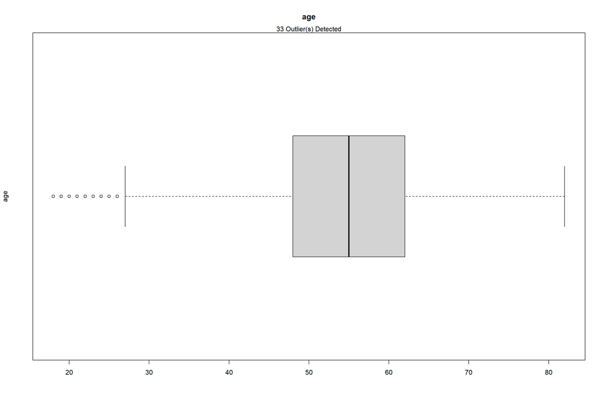

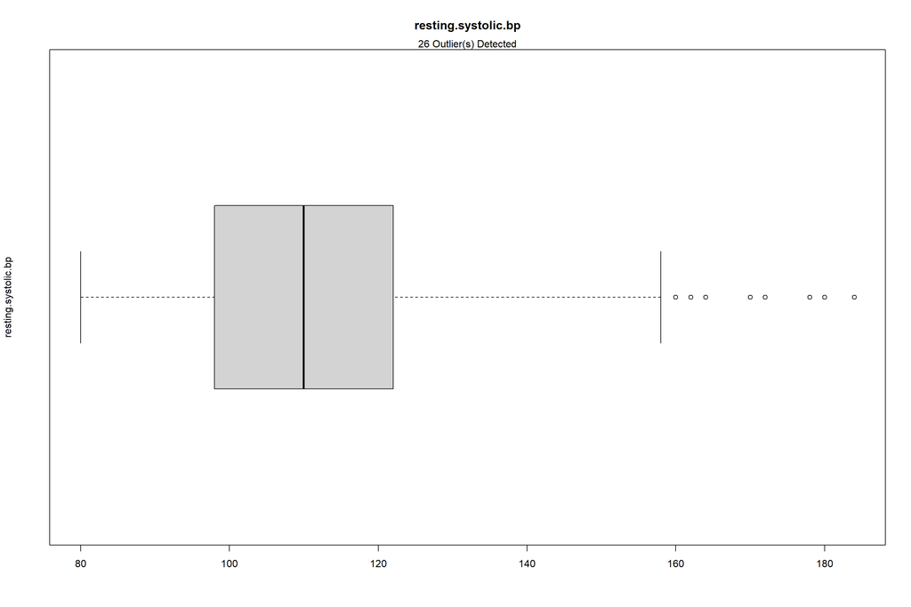

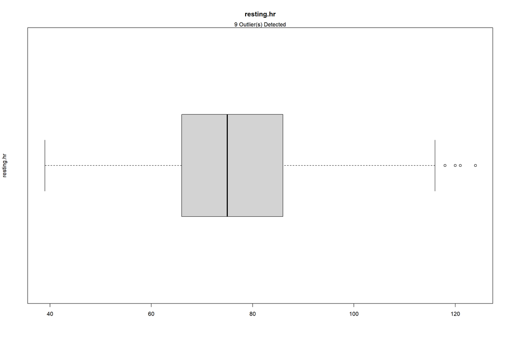

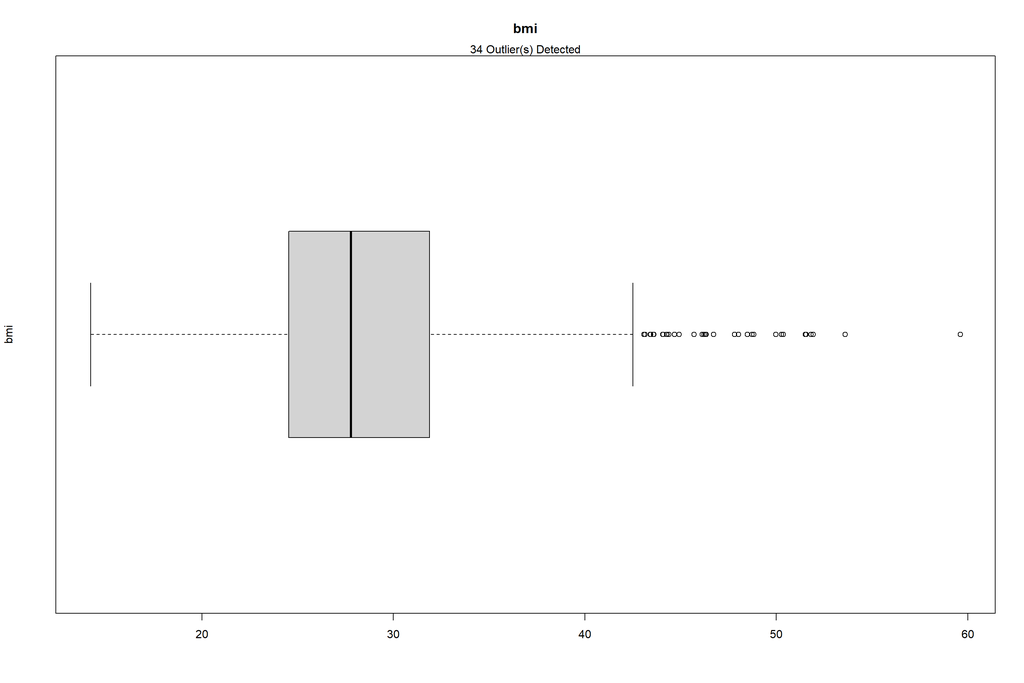

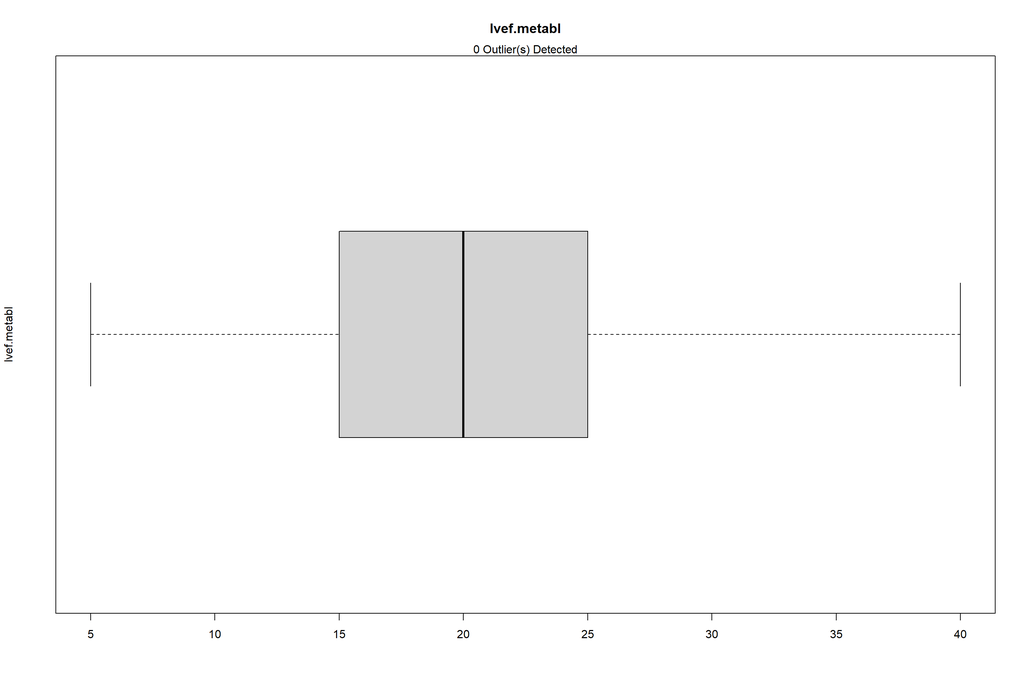

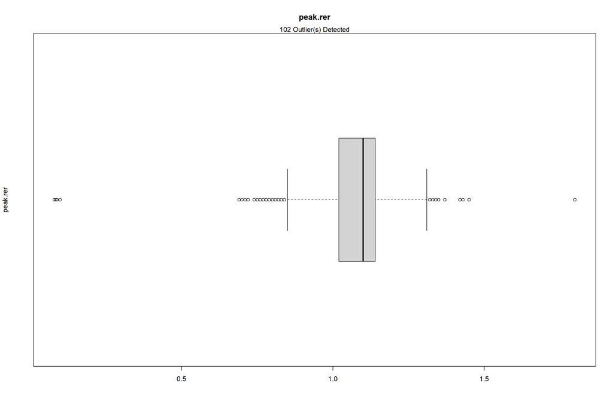

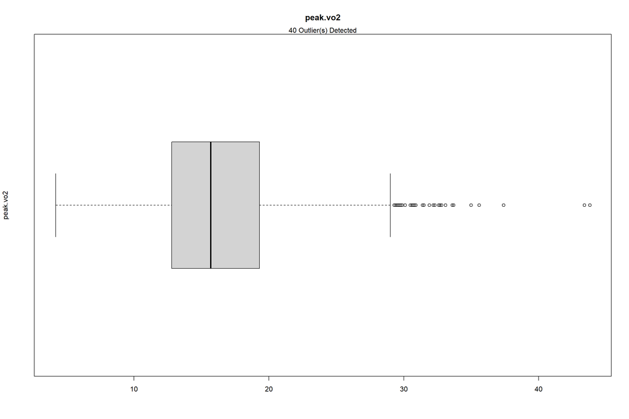

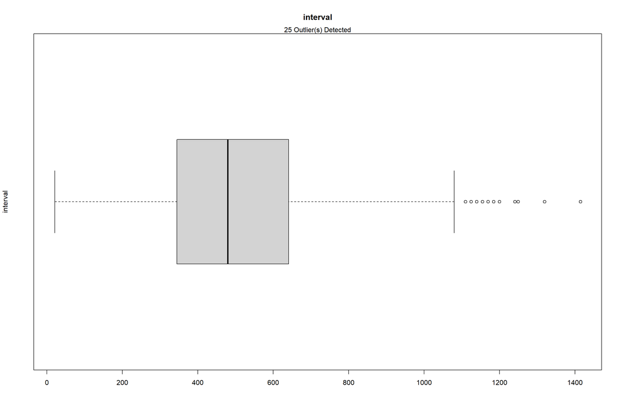

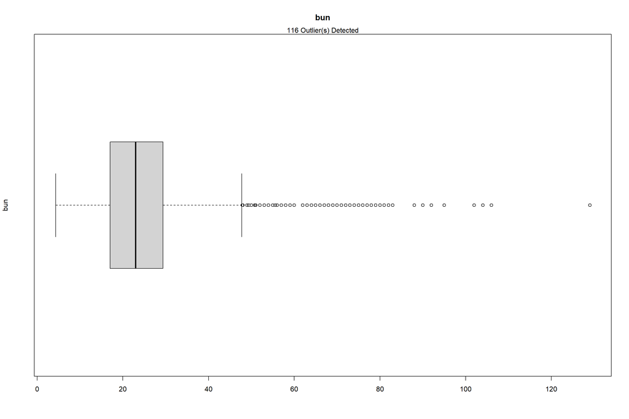

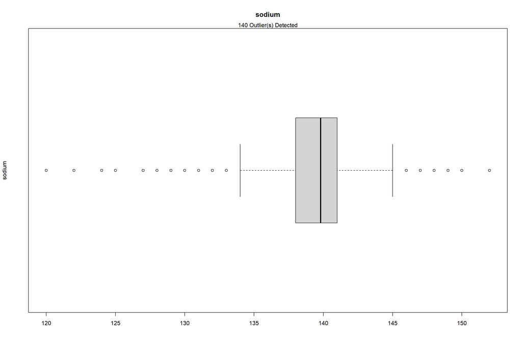

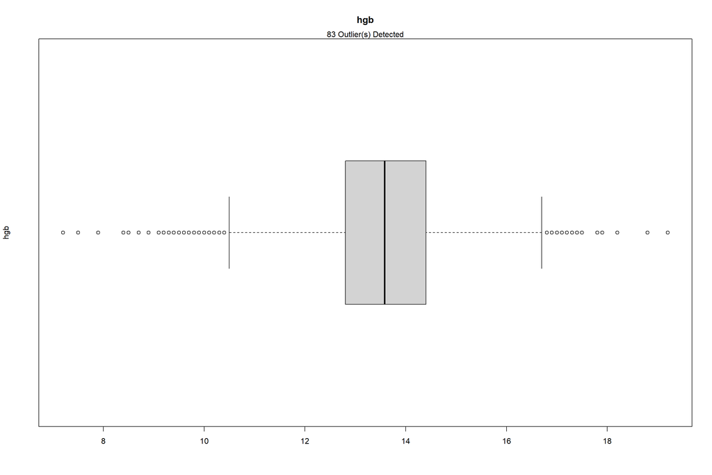

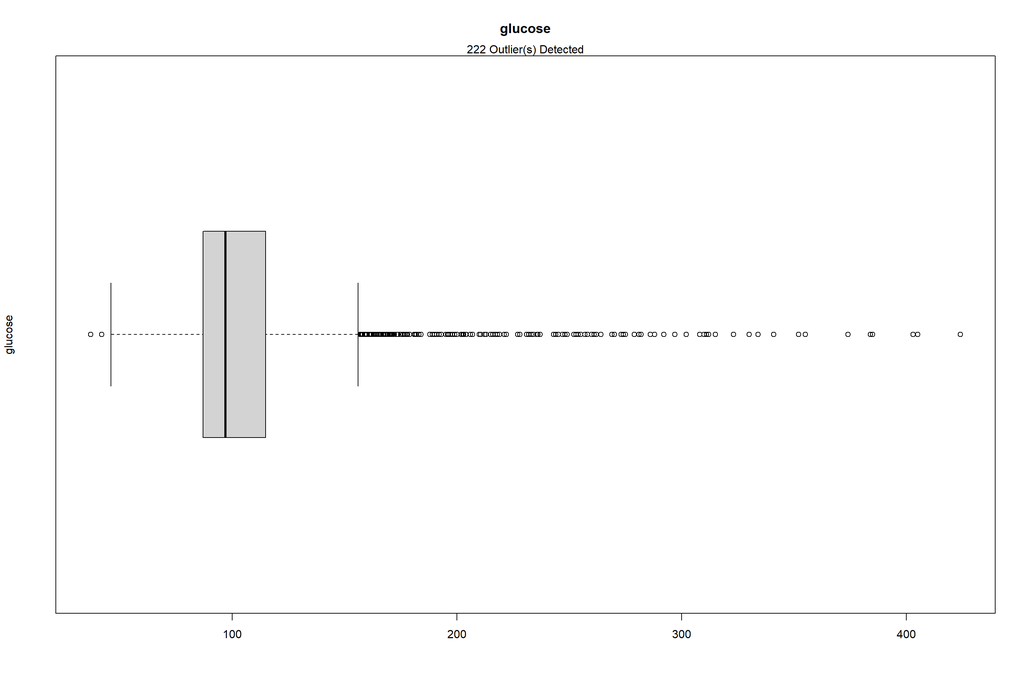

[1 more figures not shown]

```r
##################################
# Loading dataset
##################################
DPA <- peakVO2

##################################
# Listing all predictors
##################################
DPA.Predictors <- DPA[,!names(DPA) %in% c("died","ttodead")]

##################################
# Listing all numeric predictors
##################################
DPA.Predictors.Numeric <- DPA.Predictors[,sapply(DPA.Predictors, is.numeric)]

##################################
# Identifying outliers for the numeric predictors
##################################
OutlierCountList <- c()

for (i in 1:ncol(DPA.Predictors.Numeric)) {
  Outliers <- boxplot.stats(DPA.Predictors.Numeric[,i])$out
  OutlierCount <- length(Outliers)
  OutlierCountList <- append(OutlierCountList,OutlierCount)
  OutlierIndices <- which(DPA.Predictors.Numeric[,i] %in% c(Outliers))
  boxplot(DPA.Predictors.Numeric[,i],
          ylab = names(DPA.Predictors.Numeric)[i],
          main = names(DPA.Predictors.Numeric)[i],
          horizontal=TRUE)
  mtext(paste0(OutlierCount, " Outlier(s) Detected"))
}
```

```r
OutlierCountSummary <- as.data.frame(cbind(names(DPA.Predictors.Numeric),(OutlierCountList)))
names(OutlierCountSummary) <- c("NumericPredictors","OutlierCount")
OutlierCountSummary$OutlierCount <- as.numeric(as.character(OutlierCountSummary$OutlierCount))
NumericPredictorWithOutlierCount <- nrow(OutlierCountSummary[OutlierCountSummary$OutlierCount>0,])
print(paste0(NumericPredictorWithOutlierCount, " numeric variable(s) were noted with outlier(s)." ))
```

```
## [1] "12 numeric variable(s) were noted with outlier(s)."
```

```r
##################################
# Gathering descriptive statistics
##################################
(DPA_Skimmed <- skim(DPA.Predictors.Numeric))
```

Data summary

| Name | DPA.Predictors.Numeric |
| --- | --- |
| Number of rows | 2231 |
| Number of columns | 13 |
| _______________________ |  |
| Column type frequency: |  |
| numeric | 13 |
| ________________________ |  |
| Group variables | None |

**Variable type: numeric**

| skim_variable | n_missing | complete_rate | mean | sd | p0 | p25 | p50 | p75 | p100 | hist |
| --- | --- | --- | --- | --- | --- | --- | --- | --- | --- | --- |
| age | 0 | 1 | 54.22 | 11.03 | 18.00 | 48.00 | 55.00 | 62.00 | 82.00 | ▁▃▇▇▂ |
| resting.systolic.bp | 0 | 1 | 110.51 | 17.93 | 80.00 | 98.00 | 110.00 | 122.00 | 184.00 | ▇▇▅▁▁ |
| resting.hr | 0 | 1 | 76.18 | 14.39 | 39.00 | 66.00 | 75.00 | 86.00 | 124.00 | ▂▇▇▃▁ |
| bmi | 0 | 1 | 28.50 | 5.69 | 14.18 | 24.52 | 27.78 | 31.89 | 59.62 | ▂▇▃▁▁ |
| lvef.metabl | 0 | 1 | 20.26 | 7.34 | 5.00 | 15.00 | 20.00 | 25.00 | 40.00 | ▂▅▇▂▁ |
| peak.rer | 0 | 1 | 1.08 | 0.12 | 0.08 | 1.02 | 1.10 | 1.14 | 1.80 | ▁▁▇▆▁ |
| peak.vo2 | 0 | 1 | 16.27 | 5.03 | 4.20 | 12.80 | 15.70 | 19.30 | 43.80 | ▃▇▂▁▁ |
| interval | 0 | 1 | 503.26 | 220.86 | 21.00 | 345.00 | 480.00 | 641.00 | 1415.00 | ▃▇▅▁▁ |
| bun | 0 | 1 | 25.28 | 12.57 | 4.32 | 17.00 | 23.00 | 29.33 | 129.00 | ▇▂▁▁▁ |
| sodium | 0 | 1 | 139.45 | 3.09 | 120.00 | 138.00 | 139.80 | 141.00 | 152.00 | ▁▁▆▇▁ |
| hgb | 0 | 1 | 13.54 | 1.41 | 7.20 | 12.80 | 13.58 | 14.40 | 19.20 | ▁▂▇▃▁ |
| glucose | 0 | 1 | 109.35 | 42.56 | 37.00 | 87.00 | 96.93 | 114.88 | 424.00 | ▇▂▁▁▁ |
| crcl | 0 | 1 | 90.71 | 43.05 | 5.76 | 60.93 | 83.13 | 110.33 | 385.84 | ▇▇▁▁▁ |

```r
###################################
# Verifying the data dimensions
###################################
dim(DPA.Predictors.Numeric)
```

```
## [1] 2231   13
```

### 1.3.2 Zero and Near-Zero Variance

Zero and near-zero variance data assessment:  
**[A]** Low variance noted for 10 variables from the previous data quality assessment using a lower threshold.  
**[B]** Low variance noted for 2 variables using a preprocessing summary from the **caret** package. The nearZeroVar method using both the freqCut and uniqueCut criteria set at 95/5 and 10, respectively, were applied on the dataset.  
**[B.1]** dilver variable (factor)  
**[B.2]** nifed variable (factor)

**Code Chunk | Output**

```r
##################################
# Loading dataset
##################################
DPA <- peakVO2

##################################
# Gathering descriptive statistics
##################################
(DPA_Skimmed <- skim(DPA))
```

Data summary

| Name | DPA |
| --- | --- |
| Number of rows | 2231 |
| Number of columns | 41 |
| _______________________ |  |
| Column type frequency: |  |
| factor | 27 |
| numeric | 14 |
| ________________________ |  |
| Group variables | None |

**Variable type: factor**

| skim_variable | n_missing | complete_rate | ordered | n_unique | top_counts |
| --- | --- | --- | --- | --- | --- |
| betablok | 0 | 1 | FALSE | 2 | 1: 1429, 0: 802 |
| dilver | 0 | 1 | FALSE | 2 | 0: 2215, 1: 16 |
| nifed | 0 | 1 | FALSE | 2 | 0: 2132, 1: 99 |
| acei | 0 | 1 | FALSE | 2 | 1: 1711, 0: 520 |
| angioten.II | 0 | 1 | FALSE | 2 | 0: 1941, 1: 290 |
| anti.arrhy | 0 | 1 | FALSE | 2 | 0: 1722, 1: 509 |
| anti.coag | 0 | 1 | FALSE | 2 | 0: 1332, 1: 899 |
| aspirin | 0 | 1 | FALSE | 2 | 0: 1193, 1: 1038 |
| digoxin | 0 | 1 | FALSE | 2 | 1: 1570, 0: 661 |
| nitrates | 0 | 1 | FALSE | 2 | 0: 1492, 1: 739 |
| vasodilator | 0 | 1 | FALSE | 2 | 0: 2095, 1: 136 |
| diuretic.loop | 0 | 1 | FALSE | 2 | 1: 1880, 0: 351 |
| diuretic.thiazide | 0 | 1 | FALSE | 2 | 0: 1952, 1: 279 |
| diuretic.potassium.spar | 0 | 1 | FALSE | 2 | 0: 1582, 1: 649 |
| lipidrx.statin | 0 | 1 | FALSE | 2 | 0: 1381, 1: 850 |
| insulin | 0 | 1 | FALSE | 2 | 0: 2016, 1: 215 |
| surgery.pacemaker | 0 | 1 | FALSE | 2 | 0: 1729, 1: 502 |
| surgery.cabg | 0 | 1 | FALSE | 2 | 0: 1637, 1: 594 |
| surgery.pci | 0 | 1 | FALSE | 2 | 0: 1755, 1: 476 |
| surgery.aicd.implant | 0 | 1 | FALSE | 2 | 0: 1584, 1: 647 |
| smknow | 0 | 1 | FALSE | 2 | 0: 1772, 1: 459 |
| q.wave.mi | 0 | 1 | FALSE | 2 | 0: 1952, 1: 279 |
| niddm | 0 | 1 | FALSE | 2 | 0: 1881, 1: 350 |
| cad | 0 | 1 | FALSE | 2 | 0: 1325, 1: 906 |
| died | 0 | 1 | FALSE | 2 | 0: 1505, 1: 726 |
| male | 0 | 1 | FALSE | 2 | 1: 1629, 0: 602 |
| black | 0 | 1 | FALSE | 2 | 0: 1965, 1: 266 |

**Variable type: numeric**

| skim_variable | n_missing | complete_rate | mean | sd | p0 | p25 | p50 | p75 | p100 | hist |
| --- | --- | --- | --- | --- | --- | --- | --- | --- | --- | --- |
| age | 0 | 1 | 54.22 | 11.03 | 18.00 | 48.00 | 55.00 | 62.00 | 82.00 | ▁▃▇▇▂ |
| resting.systolic.bp | 0 | 1 | 110.51 | 17.93 | 80.00 | 98.00 | 110.00 | 122.00 | 184.00 | ▇▇▅▁▁ |
| resting.hr | 0 | 1 | 76.18 | 14.39 | 39.00 | 66.00 | 75.00 | 86.00 | 124.00 | ▂▇▇▃▁ |
| bmi | 0 | 1 | 28.50 | 5.69 | 14.18 | 24.52 | 27.78 | 31.89 | 59.62 | ▂▇▃▁▁ |
| lvef.metabl | 0 | 1 | 20.26 | 7.34 | 5.00 | 15.00 | 20.00 | 25.00 | 40.00 | ▂▅▇▂▁ |
| peak.rer | 0 | 1 | 1.08 | 0.12 | 0.08 | 1.02 | 1.10 | 1.14 | 1.80 | ▁▁▇▆▁ |
| peak.vo2 | 0 | 1 | 16.27 | 5.03 | 4.20 | 12.80 | 15.70 | 19.30 | 43.80 | ▃▇▂▁▁ |
| interval | 0 | 1 | 503.26 | 220.86 | 21.00 | 345.00 | 480.00 | 641.00 | 1415.00 | ▃▇▅▁▁ |
| ttodead | 0 | 1 | 62.75 | 36.77 | 1.00 | 30.00 | 62.00 | 95.00 | 127.00 | ▇▇▇▇▇ |
| bun | 0 | 1 | 25.28 | 12.57 | 4.32 | 17.00 | 23.00 | 29.33 | 129.00 | ▇▂▁▁▁ |
| sodium | 0 | 1 | 139.45 | 3.09 | 120.00 | 138.00 | 139.80 | 141.00 | 152.00 | ▁▁▆▇▁ |
| hgb | 0 | 1 | 13.54 | 1.41 | 7.20 | 12.80 | 13.58 | 14.40 | 19.20 | ▁▂▇▃▁ |
| glucose | 0 | 1 | 109.35 | 42.56 | 37.00 | 87.00 | 96.93 | 114.88 | 424.00 | ▇▂▁▁▁ |
| crcl | 0 | 1 | 90.71 | 43.05 | 5.76 | 60.93 | 83.13 | 110.33 | 385.84 | ▇▇▁▁▁ |

```r
##################################
# Identifying columns with low variance
###################################
DPA_LowVariance <- nearZeroVar(DPA,
                               freqCut = 95/5,
                               uniqueCut = 10,
                               saveMetrics= TRUE)
(DPA_LowVariance[DPA_LowVariance$nzv,])
```

```
##        freqRatio percentUnique zeroVar  nzv
## dilver 138.43750     0.0896459   FALSE TRUE
## nifed   21.53535     0.0896459   FALSE TRUE
```

```r
if ((nrow(DPA_LowVariance[DPA_LowVariance$nzv,]))==0){

  print("No low variance predictors noted.")

} else {

  print(paste0("Low variance observed for ",
               (nrow(DPA_LowVariance[DPA_LowVariance$nzv,])),
               " numeric variable(s) with First.Second.Mode.Ratio>4 and Unique.Count.Ratio<0.10."))

  DPA_LowVarianceForRemoval <- (nrow(DPA_LowVariance[DPA_LowVariance$nzv,]))

  print(paste0("Low variance can be resolved by removing ",
               (nrow(DPA_LowVariance[DPA_LowVariance$nzv,])),
               " numeric variable(s)."))

  for (j in 1:DPA_LowVarianceForRemoval) {
  DPA_LowVarianceRemovedVariable <- rownames(DPA_LowVariance[DPA_LowVariance$nzv,])[j]
  print(paste0("Variable ",
               j,
               " for removal: ",
               DPA_LowVarianceRemovedVariable))
  }

  DPA %>%
  skim() %>%
  dplyr::filter(skim_variable %in% rownames(DPA_LowVariance[DPA_LowVariance$nzv,]))

  ##################################
  # Filtering out columns with low variance
  #################################
  DPA_ExcludedLowVariance <- DPA[,!names(DPA) %in% rownames(DPA_LowVariance[DPA_LowVariance$nzv,])]

  ##################################
  # Gathering descriptive statistics
  ##################################
  (DPA_ExcludedLowVariance_Skimmed <- skim(DPA_ExcludedLowVariance))
}
```

```
## [1] "Low variance observed for 2 numeric variable(s) with First.Second.Mode.Ratio>4 and Unique.Count.Ratio<0.10."
## [1] "Low variance can be resolved by removing 2 numeric variable(s)."
## [1] "Variable 1 for removal: dilver"
## [1] "Variable 2 for removal: nifed"
```

Data summary

| Name | DPA_ExcludedLowVariance |
| --- | --- |
| Number of rows | 2231 |
| Number of columns | 39 |
| _______________________ |  |
| Column type frequency: |  |
| factor | 25 |
| numeric | 14 |
| ________________________ |  |
| Group variables | None |

**Variable type: factor**

| skim_variable | n_missing | complete_rate | ordered | n_unique | top_counts |
| --- | --- | --- | --- | --- | --- |
| betablok | 0 | 1 | FALSE | 2 | 1: 1429, 0: 802 |
| acei | 0 | 1 | FALSE | 2 | 1: 1711, 0: 520 |
| angioten.II | 0 | 1 | FALSE | 2 | 0: 1941, 1: 290 |
| anti.arrhy | 0 | 1 | FALSE | 2 | 0: 1722, 1: 509 |
| anti.coag | 0 | 1 | FALSE | 2 | 0: 1332, 1: 899 |
| aspirin | 0 | 1 | FALSE | 2 | 0: 1193, 1: 1038 |
| digoxin | 0 | 1 | FALSE | 2 | 1: 1570, 0: 661 |
| nitrates | 0 | 1 | FALSE | 2 | 0: 1492, 1: 739 |
| vasodilator | 0 | 1 | FALSE | 2 | 0: 2095, 1: 136 |
| diuretic.loop | 0 | 1 | FALSE | 2 | 1: 1880, 0: 351 |
| diuretic.thiazide | 0 | 1 | FALSE | 2 | 0: 1952, 1: 279 |
| diuretic.potassium.spar | 0 | 1 | FALSE | 2 | 0: 1582, 1: 649 |
| lipidrx.statin | 0 | 1 | FALSE | 2 | 0: 1381, 1: 850 |
| insulin | 0 | 1 | FALSE | 2 | 0: 2016, 1: 215 |
| surgery.pacemaker | 0 | 1 | FALSE | 2 | 0: 1729, 1: 502 |
| surgery.cabg | 0 | 1 | FALSE | 2 | 0: 1637, 1: 594 |
| surgery.pci | 0 | 1 | FALSE | 2 | 0: 1755, 1: 476 |
| surgery.aicd.implant | 0 | 1 | FALSE | 2 | 0: 1584, 1: 647 |
| smknow | 0 | 1 | FALSE | 2 | 0: 1772, 1: 459 |
| q.wave.mi | 0 | 1 | FALSE | 2 | 0: 1952, 1: 279 |
| niddm | 0 | 1 | FALSE | 2 | 0: 1881, 1: 350 |
| cad | 0 | 1 | FALSE | 2 | 0: 1325, 1: 906 |
| died | 0 | 1 | FALSE | 2 | 0: 1505, 1: 726 |
| male | 0 | 1 | FALSE | 2 | 1: 1629, 0: 602 |
| black | 0 | 1 | FALSE | 2 | 0: 1965, 1: 266 |

**Variable type: numeric**

| skim_variable | n_missing | complete_rate | mean | sd | p0 | p25 | p50 | p75 | p100 | hist |
| --- | --- | --- | --- | --- | --- | --- | --- | --- | --- | --- |
| age | 0 | 1 | 54.22 | 11.03 | 18.00 | 48.00 | 55.00 | 62.00 | 82.00 | ▁▃▇▇▂ |
| resting.systolic.bp | 0 | 1 | 110.51 | 17.93 | 80.00 | 98.00 | 110.00 | 122.00 | 184.00 | ▇▇▅▁▁ |
| resting.hr | 0 | 1 | 76.18 | 14.39 | 39.00 | 66.00 | 75.00 | 86.00 | 124.00 | ▂▇▇▃▁ |
| bmi | 0 | 1 | 28.50 | 5.69 | 14.18 | 24.52 | 27.78 | 31.89 | 59.62 | ▂▇▃▁▁ |
| lvef.metabl | 0 | 1 | 20.26 | 7.34 | 5.00 | 15.00 | 20.00 | 25.00 | 40.00 | ▂▅▇▂▁ |
| peak.rer | 0 | 1 | 1.08 | 0.12 | 0.08 | 1.02 | 1.10 | 1.14 | 1.80 | ▁▁▇▆▁ |
| peak.vo2 | 0 | 1 | 16.27 | 5.03 | 4.20 | 12.80 | 15.70 | 19.30 | 43.80 | ▃▇▂▁▁ |
| interval | 0 | 1 | 503.26 | 220.86 | 21.00 | 345.00 | 480.00 | 641.00 | 1415.00 | ▃▇▅▁▁ |
| ttodead | 0 | 1 | 62.75 | 36.77 | 1.00 | 30.00 | 62.00 | 95.00 | 127.00 | ▇▇▇▇▇ |
| bun | 0 | 1 | 25.28 | 12.57 | 4.32 | 17.00 | 23.00 | 29.33 | 129.00 | ▇▂▁▁▁ |
| sodium | 0 | 1 | 139.45 | 3.09 | 120.00 | 138.00 | 139.80 | 141.00 | 152.00 | ▁▁▆▇▁ |
| hgb | 0 | 1 | 13.54 | 1.41 | 7.20 | 12.80 | 13.58 | 14.40 | 19.20 | ▁▂▇▃▁ |
| glucose | 0 | 1 | 109.35 | 42.56 | 37.00 | 87.00 | 96.93 | 114.88 | 424.00 | ▇▂▁▁▁ |
| crcl | 0 | 1 | 90.71 | 43.05 | 5.76 | 60.93 | 83.13 | 110.33 | 385.84 | ▇▇▁▁▁ |

### 1.3.3 Collinearity

High collinearity data assessment:  
**[A]** No high correlation > 95% noted for any variable pairs as confirmed using the preprocessing summaries from the **caret** and **lares** packages.

**Code Chunk | Output**

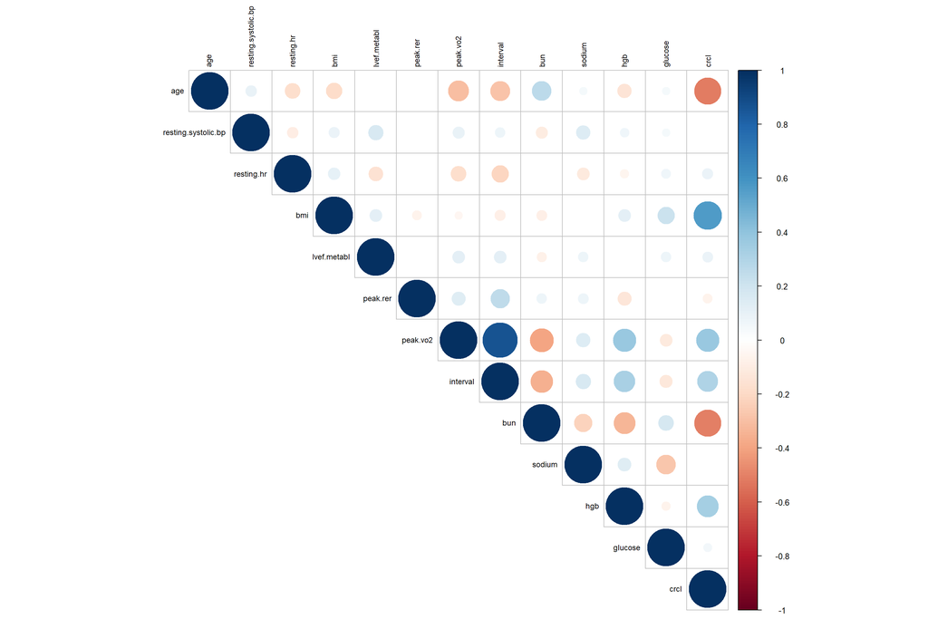

```r
##################################
# Loading dataset
##################################
DPA <- peakVO2

##################################
# Listing all predictors
##################################
DPA.Predictors <- DPA[,!names(DPA) %in% c("died","ttodead")]

##################################
# Listing all numeric predictors
##################################
DPA.Predictors.Numeric <- DPA.Predictors[,sapply(DPA.Predictors, is.numeric)]

##################################
# Visualizing pairwise correlation between predictors
##################################
DPA_CorrelationTest <- cor.mtest(DPA.Predictors.Numeric,
                       method = "pearson",
                       conf.level = .95)

corrplot(cor(DPA.Predictors.Numeric,
             method = "pearson",
             use="pairwise.complete.obs"),
         method = "circle",
         type = "upper",
         order = "original",
         tl.col = "black",
         tl.cex = 0.75,
         tl.srt = 90,
         sig.level = 0.05,
         p.mat = DPA_CorrelationTest$p,
         insig = "blank")
```

```r
##################################
# Identifying the highly correlated variables
##################################
DPA_Correlation <-  cor(DPA.Predictors.Numeric,
                        method = "pearson",
                        use="pairwise.complete.obs")
(DPA_HighlyCorrelatedCount <- sum(abs(DPA_Correlation[upper.tri(DPA_Correlation)]) > 0.95))
```

```
## [1] 0
```

```r
if (DPA_HighlyCorrelatedCount == 0) {
  print("No highly correlated predictors noted.")
} else {
  print(paste0("High correlation observed for ",
               (DPA_HighlyCorrelatedCount),
               " pairs of numeric variable(s) with Correlation.Coefficient>0.95."))

  (DPA_HighlyCorrelatedPairs <- corr_cross(DPA.Predictors.Numeric,
  max_pvalue = 0.05,
  top = DPA_HighlyCorrelatedCount,
  rm.na = TRUE,
  grid = FALSE
))

}
```

```
## [1] "No highly correlated predictors noted."
```

```r
if (DPA_HighlyCorrelatedCount > 0) {
  DPA_HighlyCorrelated <- findCorrelation(DPA_Correlation, cutoff = 0.95)

  (DPA_HighlyCorrelatedForRemoval <- length(DPA_HighlyCorrelated))

  print(paste0("High correlation can be resolved by removing ",
               (DPA_HighlyCorrelatedForRemoval),
               " numeric variable(s)."))

  for (j in 1:DPA_HighlyCorrelatedForRemoval) {
  DPA_HighlyCorrelatedRemovedVariable <- colnames(DPA.Predictors.Numeric)[DPA_HighlyCorrelated[j]]
  print(paste0("Variable ",
               j,
               " for removal: ",
               DPA_HighlyCorrelatedRemovedVariable))
  }

  ##################################
  # Filtering out columns with high correlation
  #################################
  DPA_ExcludedHighCorrelation <- DPA[,-DPA_HighlyCorrelated]

  ##################################
  # Gathering descriptive statistics
  ##################################
  (DPA_ExcludedHighCorrelation_Skimmed <- skim(DPA_ExcludedHighCorrelation))

}
```

### 1.3.4 Linear Dependencies

Linear dependency data assessment:  
**[A]** No linear dependencies noted for any subset of variables using the preprocessing summary from the **caret** package applying the findLinearCombos method which utilizes the QR decomposition of a matrix to enumerate sets of linear combinations (if they exist).

**Code Chunk | Output**

```r
##################################
# Loading dataset
##################################
DPA <- peakVO2

##################################
# Listing all predictors
##################################
DPA.Predictors <- DPA[,!names(DPA) %in% c("died","ttodead")]

##################################
# Listing all numeric predictors
##################################
DPA.Predictors.Numeric <- DPA.Predictors[,sapply(DPA.Predictors, is.numeric)]

##################################
# Identifying the linearly dependent variables
##################################
DPA_LinearlyDependent <- findLinearCombos(DPA.Predictors.Numeric)

(DPA_LinearlyDependentCount <- length(DPA_LinearlyDependent$linearCombos))
```

```
## [1] 0
```

```r
if (DPA_LinearlyDependentCount == 0) {
  print("No linearly dependent predictors noted.")
} else {
  print(paste0("Linear dependency observed for ",
               (DPA_LinearlyDependentCount),
               " subset(s) of numeric variable(s)."))

  for (i in 1:DPA_LinearlyDependentCount) {
    DPA_LinearlyDependentSubset <- colnames(DPA.Predictors.Numeric)[DPA_LinearlyDependent$linearCombos[[i]]]
    print(paste0("Linear dependent variable(s) for subset ",
                 i,
                 " include: ",
                 DPA_LinearlyDependentSubset))
  }

}
```

```
## [1] "No linearly dependent predictors noted."
```

```r
##################################
# Identifying the linearly dependent variables for removal
##################################

if (DPA_LinearlyDependentCount > 0) {
  DPA_LinearlyDependent <- findLinearCombos(DPA.Predictors.Numeric)

  DPA_LinearlyDependentForRemoval <- length(DPA_LinearlyDependent$remove)

  print(paste0("Linear dependency can be resolved by removing ",
               (DPA_LinearlyDependentForRemoval),
               " numeric variable(s)."))

  for (j in 1:DPA_LinearlyDependentForRemoval) {
  DPA_LinearlyDependentRemovedVariable <- colnames(DPA.Predictors.Numeric)[DPA_LinearlyDependent$remove[j]]
  print(paste0("Variable ",
               j,
               " for removal: ",
               DPA_LinearlyDependentRemovedVariable))
  }

  ##################################
  # Filtering out columns with linear dependency
  #################################
  DPA_ExcludedLinearlyDependent <- DPA[,-DPA_LinearlyDependent$remove]

  ##################################
  # Gathering descriptive statistics
  ##################################
  (DPA_ExcludedLinearlyDependent_Skimmed <- skim(DPA_ExcludedLinearlyDependent))

}
```

### 1.3.5 Univariate Filter

**Code Chunk | Output**

```r
##################################
# Formulating the univariate Cox PH models
# to assess the predictive power
# of the individual predictors
##################################

##################################
# Loading dataset
##################################
UF <- peakVO2.Source

##################################
# Formulating the response
# and predictor variables
##################################
UF_Response <- Surv(time=UF$ttodead, event=UF$died)

UF_Predictors <- names(UF)[!names(UF) %in% c("ttodead","died")]

##################################
# Formulating the response
# and predictor variables
##################################

(UF_CoxPHFormula <- sapply(UF_Predictors,
                          function(x) as.formula(paste('Surv(ttodead,died)~', x))))
```

```
## $age
## Surv(ttodead, died) ~ age
## <environment: 0x000000002ab653e8>
##
## $betablok
## Surv(ttodead, died) ~ betablok
## <environment: 0x000000002ab5fbc8>
##
## $dilver
## Surv(ttodead, died) ~ dilver
## <environment: 0x000000002a9e5550>
##
## $nifed
## Surv(ttodead, died) ~ nifed
## <environment: 0x000000002a9e3048>
##
## $acei
## Surv(ttodead, died) ~ acei
## <environment: 0x000000002a9e0ad0>
##
## $angioten.II
## Surv(ttodead, died) ~ angioten.II
## <environment: 0x000000002a9de558>
##
## $anti.arrhy
## Surv(ttodead, died) ~ anti.arrhy
## <environment: 0x000000002a9dff98>
##
## $anti.coag
## Surv(ttodead, died) ~ anti.coag
## <environment: 0x000000002a9dde10>
##
## $aspirin
## Surv(ttodead, died) ~ aspirin
## <environment: 0x000000002a9db978>
##
## $digoxin
## Surv(ttodead, died) ~ digoxin
## <environment: 0x000000002a9d97b8>
##
```

[output cut: 100 more lines]

```
## $glucose
## Surv(ttodead, died) ~ glucose
## <environment: 0x000000002a994fe8>
##
## $male
## Surv(ttodead, died) ~ male
## <environment: 0x000000002a992c68>
##
## $black
## Surv(ttodead, died) ~ black
## <environment: 0x000000002a990958>
##
## $crcl
## Surv(ttodead, died) ~ crcl
## <environment: 0x000000002a98e760>
```

```r
(UF_CoxPHModel <- lapply(UF_CoxPHFormula, function(x){coxph(x, data=UF)}))
```

```
## $age
## Call:
## coxph(formula = x, data = UF)
##
##         coef exp(coef) se(coef)     z        p
## age 0.025359  1.025684 0.003585 7.074 1.51e-12
##
## Likelihood ratio test=51.92  on 1 df, p=5.784e-13
## n= 2231, number of events= 726
##
## $betablok
## Call:
## coxph(formula = x, data = UF)
##
##              coef exp(coef) se(coef)      z        p
## betablok -0.36995   0.69077  0.07482 -4.945 7.62e-07
##
## Likelihood ratio test=24.2  on 1 df, p=8.693e-07
## n= 2231, number of events= 726
##
## $dilver
## Call:
## coxph(formula = x, data = UF)
##
##           coef exp(coef) se(coef)      z     p
## dilver -0.2607    0.7705   0.4488 -0.581 0.561
##
## Likelihood ratio test=0.37  on 1 df, p=0.544
## n= 2231, number of events= 726
##
## $nifed
## Call:
## coxph(formula = x, data = UF)
##
##         coef exp(coef) se(coef)     z     p
## nifed 0.1629    1.1770   0.1710 0.953 0.341
##
## Likelihood ratio test=0.87  on 1 df, p=0.3523
## n= 2231, number of events= 726
##
```

[output cut: 334 more lines]

```
##          coef exp(coef) se(coef)     z     p
## black 0.06476   1.06690  0.11377 0.569 0.569
##
## Likelihood ratio test=0.32  on 1 df, p=0.5724
## n= 2231, number of events= 726
##
## $crcl
## Call:
## coxph(formula = x, data = UF)
##
##           coef exp(coef)  se(coef)      z        p
## crcl -0.008557  0.991480  0.001080 -7.923 2.32e-15
##
## Likelihood ratio test=72.01  on 1 df, p=< 2.2e-16
## n= 2231, number of events= 726
```

```r
UF_CoxPHModelResults <- lapply(UF_CoxPHModel,
                               function(x){
                                 x <- summary(x)
                                 p.value<-round(x$wald["pvalue"], digits=5)
                                 wald.test<-round(x$wald["test"], digits=5)

                                 ######################################
                                 # Extracting the concordance values
                                 ######################################
                                 concordance<-round(x$concordance[[1]],digits=5)

                                 ######################################
                                 # Extracting the beta coefficients
                                 ######################################
                                 beta<-round(x$coef[1], digits=5)
                                 z<-round(x$coefficients[[4]], digits=5)

                                 ######################################
                                 # Extracting the exponentiated coefficients
                                 ######################################
                                 HR <-round(x$coef[2], digits=5)
                                 HR.confint.lower <- round(x$conf.int[,"lower .95"],5)
                                 HR.confint.upper <- round(x$conf.int[,"upper .95"],5)
                                 HR <- paste0(HR, " (",
                                              HR.confint.lower, "-", HR.confint.upper, ")")

                                 ######################################
                                 # Consolidating the model results
                                 ######################################
                                 res<-c(concordance,beta, HR, z, p.value, wald.test)
                                 names(res)<-c("Concordance",
                                               "Beta",
                                               "HR (95% CI for HR)",
                                               "z",
                                               "P-Value",
                                               "Wald Test")
                                 return(res)
                       })

UF_CoxPHModelResults <- t(as.data.frame(UF_CoxPHModelResults, check.names = FALSE))

######################################
# Summarizing the results
# for all variables
######################################
UF_CoxPHModelSummary <- as.data.frame(UF_CoxPHModelResults)

######################################
# Gathering only
# the significant variables
# from the univariate Cox PH analysis
######################################
(UF_CoxPHModelSummary_Sig <- UF_CoxPHModelSummary[UF_CoxPHModelSummary$'P-Value'==0.05 |
                                                   UF_CoxPHModelSummary$'P-Value'<0.05,])
```

```
##                     Concordance     Beta        HR (95% CI for HR)         z
## age                     0.58441  0.02536  1.02568 (1.0185-1.03292)    7.0738
## betablok                0.55325 -0.36995 0.69077 (0.59656-0.79987)  -4.94481
## acei                    0.51752 -0.20395   0.8155 (0.6885-0.96594)   -2.3612
## angioten.II              0.5116  0.26978 1.30968 (1.06167-1.61561)    2.5187
## anti.arrhy              0.53265  0.29948 1.34916 (1.14492-1.58983)   3.57595
## anti.coag               0.53348  0.27124 1.31159 (1.13351-1.51766)    3.6431
## aspirin                 0.52474 -0.15459 0.85677 (0.73867-0.99374)  -2.04294
## vasodilator                0.51  0.31262 1.36701 (1.03088-1.81273)   2.17118
## diuretic.loop           0.52758  0.45458 1.57551 (1.25201-1.98259)   3.87668
## diuretic.thiazide        0.5367  0.50622   1.659 (1.36816-2.01167)   5.14751
## insulin                 0.52329  0.55057 1.73423 (1.39719-2.15258)   4.99346
## surgery.pacemaker       0.51926  0.19372   1.21376 (1.0203-1.4439)   2.18679
## surgery.cabg            0.55029  0.43581 1.54622 (1.32357-1.80632)   5.49381
## resting.systolic.bp     0.55211 -0.00796 0.99207 (0.98789-0.99626)  -3.70069
## resting.hr              0.55122  0.01146 1.01153 (1.00666-1.01642)   4.65287
## lvef.metabl              0.5631 -0.02818 0.97221 (0.96191-0.98263)  -5.18339
## peak.vo2                0.67529 -0.12907 0.87891 (0.86353-0.89456) -14.32822
## interval                0.66399 -0.00267 0.99733 (0.99696-0.99771) -13.88554
## cad                     0.55102  0.40104 1.49338 (1.29093-1.72758)   5.39554
## bun                     0.65486  0.02895 1.02937 (1.02547-1.03329)  14.94786
## sodium                  0.57751 -0.07327 0.92935 (0.90871-0.95047)  -6.39278
## hgb                      0.5851 -0.17772 0.83718 (0.79492-0.88168)  -6.72457
## glucose                 0.52923  0.00245 1.00245 (1.00093-1.00398)   3.15297
## male                    0.54481   0.4432 1.55768 (1.30089-1.86517)   4.82184
## crcl                    0.60889 -0.00856 0.99148 (0.98938-0.99358)  -7.92298
##                     P-Value Wald Test
## age                       0     50.04
## betablok                  0     24.45
## acei                0.01822      5.58
## angioten.II         0.01178      6.34
## anti.arrhy          0.00035     12.79
## anti.coag           0.00027     13.27
## aspirin             0.04106      4.17
## vasodilator         0.02992      4.71
## diuretic.loop       0.00011     15.03
## diuretic.thiazide         0      26.5
## insulin                   0     24.93
## surgery.pacemaker   0.02876      4.78
## surgery.cabg              0     30.18
## resting.systolic.bp 0.00022      13.7
## resting.hr                0     21.65
## lvef.metabl               0     26.87
## peak.vo2                  0     205.3
## interval                  0    192.81
## cad                       0     29.11
## bun                       0    223.44
## sodium                    0     40.87
## hgb                       0     45.22
## glucose             0.00162      9.94
## male                      0     23.25
## crcl                      0     62.77
```

```r
nrow(UF_CoxPHModelSummary_Sig)
```

```
## [1] 25
```

```r
rownames(UF_CoxPHModelSummary_Sig)
```

```
##  [1] "age"                 "betablok"            "acei"
##  [4] "angioten.II"         "anti.arrhy"          "anti.coag"
##  [7] "aspirin"             "vasodilator"         "diuretic.loop"
## [10] "diuretic.thiazide"   "insulin"             "surgery.pacemaker"
## [13] "surgery.cabg"        "resting.systolic.bp" "resting.hr"
## [16] "lvef.metabl"         "peak.vo2"            "interval"
## [19] "cad"                 "bun"                 "sodium"
## [22] "hgb"                 "glucose"             "male"
## [25] "crcl"
```

```r
UF_Sig <- peakVO2[,rownames(UF_CoxPHModelSummary_Sig)]

(data.frame(
  Column.Index=c(1:length(names(UF_Sig))),
  Column.Name= names(UF_Sig),
  Column.Type=sapply(UF_Sig, function(x) class(x)),
  row.names=NULL)
)
```

```
##    Column.Index         Column.Name Column.Type
## 1             1                 age     integer
## 2             2            betablok      factor
## 3             3                acei      factor
## 4             4         angioten.II      factor
## 5             5          anti.arrhy      factor
## 6             6           anti.coag      factor
## 7             7             aspirin      factor
## 8             8         vasodilator      factor
## 9             9       diuretic.loop      factor
## 10           10   diuretic.thiazide      factor
## 11           11             insulin      factor
## 12           12   surgery.pacemaker      factor
## 13           13        surgery.cabg      factor
## 14           14 resting.systolic.bp     integer
## 15           15          resting.hr     integer
## 16           16         lvef.metabl     numeric
## 17           17            peak.vo2     numeric
## 18           18            interval     integer
## 19           19                 cad      factor
## 20           20                 bun     numeric
## 21           21              sodium     numeric
## 22           22                 hgb     numeric
## 23           23             glucose     numeric
## 24           24                male      factor
## 25           25                crcl     numeric
```

```r
######################################
# Gathering only
# the non-significant variables
# from the univariate Cox PH analysis
######################################
(UF_CoxPHModelSummary_NonSig <- UF_CoxPHModelSummary[UF_CoxPHModelSummary$'P-Value'>0.05,])
```

```
##                         Concordance     Beta        HR (95% CI for HR)        z
## dilver                      0.50131  -0.2607  0.77051 (0.3197-1.85702) -0.58086
## nifed                       0.50223  0.16295 1.17697 (0.84183-1.64553)  0.95301
## digoxin                     0.53316  0.35952 1.43264 (1.19665-1.71517)  3.91482
## nitrates                     0.5138   0.1366 1.14637 (0.98524-1.33385)  1.76755
## diuretic.potassium.spar     0.50193 -0.02909 0.97133 (0.82146-1.14855) -0.34019
## lipidrx.statin              0.50006  0.00414 1.00415 (0.86216-1.16953)  0.05326
## surgery.pci                 0.50773  0.09777  1.10271 (0.9232-1.31714)  1.07849
## surgery.aicd.implant        0.51548  0.15077 1.16273 (0.98435-1.37342)  1.77437
## smknow                        0.519 -0.14929 0.86132 (0.71481-1.03786) -1.56933
## q.wave.mi                   0.50942  0.15472 1.16733 (0.94602-1.44043)  1.44255
## bmi                         0.51885 -0.00968 0.99037 (0.97742-1.00348) -1.44241
## niddm                       0.50382  0.14548 1.15659 (0.95385-1.40244)  1.47944
## peak.rer                    0.50881  0.03624   1.0369 (0.5437-1.97749)  0.11002
## black                       0.49951  0.06476   1.0669 (0.85366-1.3334)  0.56919
##                         P-Value Wald Test
## dilver                  0.56133      0.34
## nifed                   0.34059      0.91
## digoxin                   9e-05     15.33
## nitrates                0.07714      3.12
## diuretic.potassium.spar 0.73371      0.12
## lipidrx.statin          0.95752         0
## surgery.pci             0.28081      1.16
## surgery.aicd.implant      0.076      3.15
## smknow                  0.11657      2.46
## q.wave.mi               0.14915      2.08
## bmi                     0.14919      2.08
## niddm                   0.13902      2.19
## peak.rer                 0.9124      0.01
## black                   0.56923      0.32
```

```r
nrow(UF_CoxPHModelSummary_NonSig)
```

```
## [1] 14
```

```r
rownames(UF_CoxPHModelSummary_NonSig)
```

```
##  [1] "dilver"                  "nifed"
##  [3] "digoxin"                 "nitrates"
##  [5] "diuretic.potassium.spar" "lipidrx.statin"
##  [7] "surgery.pci"             "surgery.aicd.implant"
##  [9] "smknow"                  "q.wave.mi"
## [11] "bmi"                     "niddm"
## [13] "peak.rer"                "black"
```

```r
UF_NonSig <- peakVO2[,rownames(UF_CoxPHModelSummary_NonSig)]

(data.frame(
  Column.Index=c(1:length(names(UF_NonSig))),
  Column.Name= names(UF_NonSig),
  Column.Type=sapply(UF_NonSig, function(x) class(x)),
  row.names=NULL)
)
```

```
##    Column.Index             Column.Name Column.Type
## 1             1                  dilver      factor
## 2             2                   nifed      factor
## 3             3                 digoxin      factor
## 4             4                nitrates      factor
## 5             5 diuretic.potassium.spar      factor
## 6             6          lipidrx.statin      factor
## 7             7             surgery.pci      factor
## 8             8    surgery.aicd.implant      factor
## 9             9                  smknow      factor
## 10           10               q.wave.mi      factor
## 11           11                     bmi     numeric
## 12           12                   niddm      factor
## 13           13                peak.rer     numeric
## 14           14                   black      factor
```

### 1.3.6 Pre-Processed Dataset

Preliminary dataset assessment:  
**[A]** 2231 rows (observations)  
**[B]** 27 columns (variables)  
**[B.1]** 1/27 survival event status = died variable (factor)  
**[B.1.1]** Event = died=1  
**[B.1.2]** Censored or Non-Event = died=0  
**[B.2]** 1/27 survival time = ttodead variable (numeric)  
**[B.3]** 25/27 predictors = All remaining variables (14/25 factor + 11/25 numeric)  
**[C]** Pre-processing actions applied:  
**[C.1]** No centering, scaling and shape transformation applied to maintain interpretability  
**[C.2]** No outlier treatment applied since the high values noted were contextually valid and sensible  
**[C.3]** 2 predictors removed due to zero or near-zero variance  
**[C.4]** No predictors removed due to high correlation  
**[C.5]** No predictors removed due to linear dependencies  
**[C.6]** 14 predictors evaluated as not statistically significant predictors from the univariate Cox Proportional Hazards modelling analysis removed

**Code Chunk | Output**

```r
##################################
# Filtering out columns noted with data quality issues including
# zero and near-zero variance,
# to create the pre-modelling dataset
##################################
PMA_ExcludedNonSig <- peakVO2[,!names(peakVO2) %in% rownames(UF_CoxPHModelSummary_NonSig)]

PMA_PreModelling_Train <- PMA_ExcludedNonSig

##################################
# Gathering descriptive statistics
##################################
(PMA_PreModelling_Train_Skimmed <- skim(PMA_PreModelling_Train))
```

Data summary

| Name | PMA_PreModelling_Train |
| --- | --- |
| Number of rows | 2231 |
| Number of columns | 27 |
| _______________________ |  |
| Column type frequency: |  |
| factor | 15 |
| numeric | 12 |
| ________________________ |  |
| Group variables | None |

**Variable type: factor**

| skim_variable | n_missing | complete_rate | ordered | n_unique | top_counts |
| --- | --- | --- | --- | --- | --- |
| betablok | 0 | 1 | FALSE | 2 | 1: 1429, 0: 802 |
| acei | 0 | 1 | FALSE | 2 | 1: 1711, 0: 520 |
| angioten.II | 0 | 1 | FALSE | 2 | 0: 1941, 1: 290 |
| anti.arrhy | 0 | 1 | FALSE | 2 | 0: 1722, 1: 509 |
| anti.coag | 0 | 1 | FALSE | 2 | 0: 1332, 1: 899 |
| aspirin | 0 | 1 | FALSE | 2 | 0: 1193, 1: 1038 |
| vasodilator | 0 | 1 | FALSE | 2 | 0: 2095, 1: 136 |
| diuretic.loop | 0 | 1 | FALSE | 2 | 1: 1880, 0: 351 |
| diuretic.thiazide | 0 | 1 | FALSE | 2 | 0: 1952, 1: 279 |
| insulin | 0 | 1 | FALSE | 2 | 0: 2016, 1: 215 |
| surgery.pacemaker | 0 | 1 | FALSE | 2 | 0: 1729, 1: 502 |
| surgery.cabg | 0 | 1 | FALSE | 2 | 0: 1637, 1: 594 |
| cad | 0 | 1 | FALSE | 2 | 0: 1325, 1: 906 |
| died | 0 | 1 | FALSE | 2 | 0: 1505, 1: 726 |
| male | 0 | 1 | FALSE | 2 | 1: 1629, 0: 602 |

**Variable type: numeric**

| skim_variable | n_missing | complete_rate | mean | sd | p0 | p25 | p50 | p75 | p100 | hist |
| --- | --- | --- | --- | --- | --- | --- | --- | --- | --- | --- |
| age | 0 | 1 | 54.22 | 11.03 | 18.00 | 48.00 | 55.00 | 62.00 | 82.00 | ▁▃▇▇▂ |
| resting.systolic.bp | 0 | 1 | 110.51 | 17.93 | 80.00 | 98.00 | 110.00 | 122.00 | 184.00 | ▇▇▅▁▁ |
| resting.hr | 0 | 1 | 76.18 | 14.39 | 39.00 | 66.00 | 75.00 | 86.00 | 124.00 | ▂▇▇▃▁ |
| lvef.metabl | 0 | 1 | 20.26 | 7.34 | 5.00 | 15.00 | 20.00 | 25.00 | 40.00 | ▂▅▇▂▁ |
| peak.vo2 | 0 | 1 | 16.27 | 5.03 | 4.20 | 12.80 | 15.70 | 19.30 | 43.80 | ▃▇▂▁▁ |
| interval | 0 | 1 | 503.26 | 220.86 | 21.00 | 345.00 | 480.00 | 641.00 | 1415.00 | ▃▇▅▁▁ |
| ttodead | 0 | 1 | 62.75 | 36.77 | 1.00 | 30.00 | 62.00 | 95.00 | 127.00 | ▇▇▇▇▇ |
| bun | 0 | 1 | 25.28 | 12.57 | 4.32 | 17.00 | 23.00 | 29.33 | 129.00 | ▇▂▁▁▁ |
| sodium | 0 | 1 | 139.45 | 3.09 | 120.00 | 138.00 | 139.80 | 141.00 | 152.00 | ▁▁▆▇▁ |
| hgb | 0 | 1 | 13.54 | 1.41 | 7.20 | 12.80 | 13.58 | 14.40 | 19.20 | ▁▂▇▃▁ |
| glucose | 0 | 1 | 109.35 | 42.56 | 37.00 | 87.00 | 96.93 | 114.88 | 424.00 | ▇▂▁▁▁ |
| crcl | 0 | 1 | 90.71 | 43.05 | 5.76 | 60.93 | 83.13 | 110.33 | 385.84 | ▇▇▁▁▁ |

```r
###################################
# Verifying the data dimensions
# for the train set
###################################
dim(PMA_PreModelling_Train)
```

```
## [1] 2231   27
```

## 1.4 Data Exploration

Exploratory data analysis:  
**[A]** Numeric variables which demonstrated differential relationships with the ttodead and died survival time and event status variables, based on trend line correlation with survival time, include:  
**[A.1]** peak.vo2 variable (numeric)  
**[A.2]** interval variable (numeric)  
**[A.3]** sodium variable (numeric)  
**[B]** Factor variables which demonstrated differential relationships with the ttodead and died survival time and event status variables, based on the Log-Rank Test p-value and estimated Kaplan-Meier survival curve separations, include:  
**[B.1]** betablk variable (factor)  
**[B.2]** diuretic.thiazide variable (factor)  
**[B.3]** cad variable (factor)  
**[B.4]** diuretic.loop variable (factor)  
**[B.5]** male variable (factor)  
**[B.6]** surgery.cabg variable (factor)  
**[B.7]** insulin variable (factor)

**Code Chunk | Output**

```r
##################################
# Loading dataset
##################################
EDA <- PMA_PreModelling_Train

##################################
# Loading dataset
##################################
EDA.DescriptiveStatistics <- EDA

EDA.DescriptiveStatistics$died <- ifelse(EDA.DescriptiveStatistics$died=="0","Survived+Censored","Died")

##################################
# Formulating a preliminary summary
# of descriptive statistics
##################################
EDA.DescriptiveStatistics %>%
  tbl_summary(
    by = died,
    type = all_continuous() ~ "continuous2",
    statistic = all_continuous() ~ c("{N_nonmiss}",
                                     "{mean} ({sd})",
                                     "{median} ({p25}, {p75})",
                                     "{min}, {max}"),
    missing = "no") %>%
  add_overall() %>%
  add_p()
```

| **Characteristic** | **Overall**, N = 2,231<sup>1</sup> | **Died**, N = 726<sup>1</sup> | **Survived+Censored**, N = 1,505<sup>1</sup> | **p-value**<sup>2</sup> |
| --- | --- | --- | --- | --- |
| age |  |  |  | <0.001 |
| N | 2,231 | 726 | 1,505 |  |
| Mean (SD) | 54 (11) | 56 (11) | 53 (11) |  |
| Median (IQR) | 55 (48, 62) | 58 (50, 64) | 54 (46, 61) |  |
| Range | 18, 82 | 18, 82 | 19, 82 |  |
| resting.systolic.bp |  |  |  | <0.001 |
| N | 2,231 | 726 | 1,505 |  |
| Mean (SD) | 111 (18) | 108 (18) | 112 (18) |  |
| Median (IQR) | 110 (98, 122) | 108 (94, 120) | 110 (100, 122) |  |
| Range | 80, 184 | 80, 184 | 80, 184 |  |
| resting.hr |  |  |  | <0.001 |
| N | 2,231 | 726 | 1,505 |  |
| Mean (SD) | 76 (14) | 79 (14) | 75 (14) |  |
| Median (IQR) | 75 (66, 86) | 78 (68, 88) | 74 (65, 84) |  |
| Range | 39, 124 | 41, 121 | 39, 124 |  |
| lvef.metabl |  |  |  | <0.001 |
| N | 2,231 | 726 | 1,505 |  |
| Mean (SD) | 20 (7) | 19 (7) | 21 (7) |  |
| Median (IQR) | 20 (15, 25) | 20 (15, 25) | 20 (15, 25) |  |
| Range | 5, 40 | 5, 40 | 5, 40 |  |
| peak.vo2 |  |  |  | <0.001 |
| N | 2,231 | 726 | 1,505 |  |
| Mean (SD) | 16.3 (5.0) | 14.3 (4.5) | 17.2 (5.0) |  |
| Median (IQR) | 15.7 (12.8, 19.3) | 13.9 (11.2, 16.6) | 16.7 (13.6, 20.2) |  |
| Range | 4.2, 43.8 | 5.2, 43.4 | 4.2, 43.8 |  |
| interval |  |  |  | <0.001 |
| N | 2,231 | 726 | 1,505 |  |
| Mean (SD) | 503 (221) | 424 (192) | 542 (224) |  |
| Median (IQR) | 480 (345, 641) | 415 (282, 540) | 532 (375, 700) |  |
| Range | 21, 1,415 | 35, 1,250 | 21, 1,415 |  |

[output cut: 72 more lines]

<sup>1</sup> n (%)  
<sup>2</sup> Wilcoxon rank sum test; Pearson's Chi-squared test

```r
##################################
# Listing all predictors
##################################
EDA.Predictors <- EDA[,!names(EDA) %in% c("died","ttodead")]


##################################
# Listing all numeric predictors
##################################
EDA.Predictors.Numeric <- EDA.Predictors[,sapply(EDA.Predictors, is.numeric)]
ncol(EDA.Predictors.Numeric)
```

```
## [1] 11
```

```r
names(EDA.Predictors.Numeric)
```

```
##  [1] "age"                 "resting.systolic.bp" "resting.hr"
##  [4] "lvef.metabl"         "peak.vo2"            "interval"
##  [7] "bun"                 "sodium"              "hgb"
## [10] "glucose"             "crcl"
```

```r
##################################
# Listing all factor predictors
##################################
EDA.Predictors.Factor <- EDA.Predictors[,sapply(EDA.Predictors, is.factor)]
ncol(EDA.Predictors.Factor)
```

```
## [1] 14
```

```r
names(EDA.Predictors.Factor)
```

```
##  [1] "betablok"          "acei"              "angioten.II"
##  [4] "anti.arrhy"        "anti.coag"         "aspirin"
##  [7] "vasodilator"       "diuretic.loop"     "diuretic.thiazide"
## [10] "insulin"           "surgery.pacemaker" "surgery.cabg"
## [13] "cad"               "male"
```

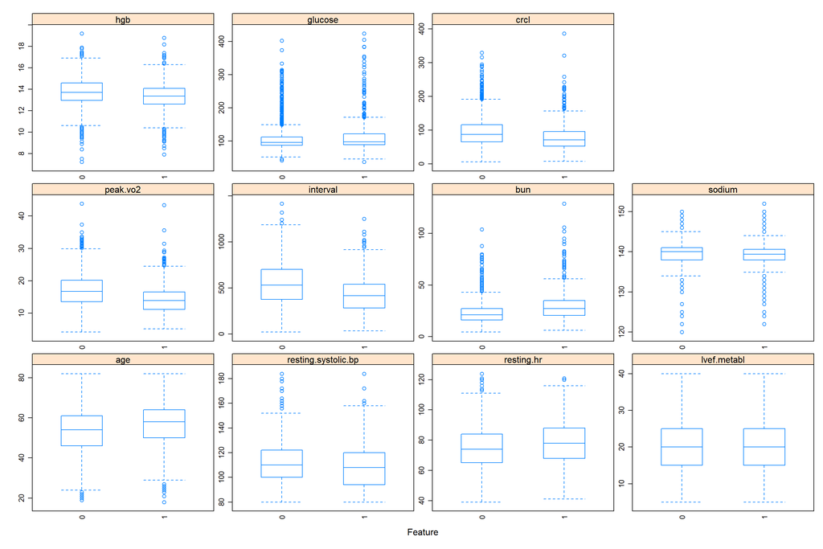

```r
##################################
# Formulating the box plots
##################################
featurePlot(x = EDA.Predictors.Numeric,
            y = EDA$died,
            plot = "box",
            scales = list(x = list(relation="free", rot = 90),
                          y = list(relation="free")),
            adjust = 1.5,
            pch = "|")
```

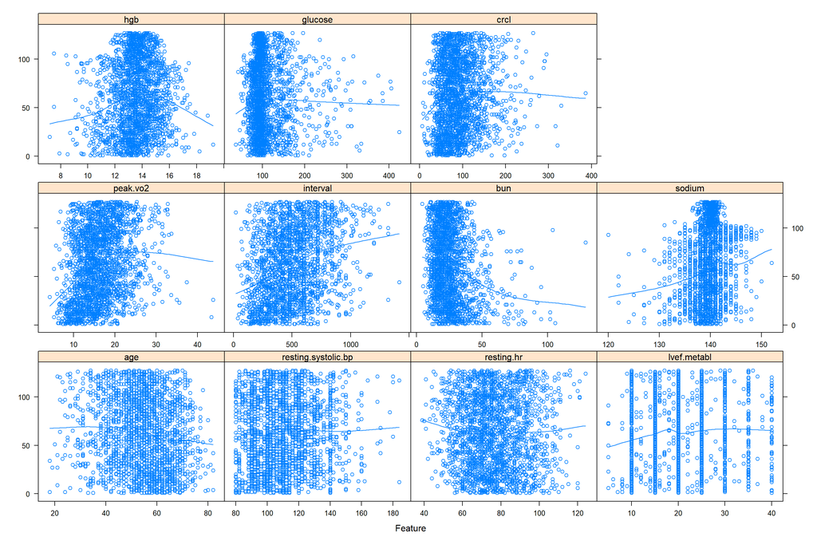

```r
##################################
# Formulating the scatter plot
##################################
featurePlot(x = EDA.Predictors.Numeric,
            y = EDA$ttodead,
            plot = "scatter",
            type = c("p", "smooth"),
            span = .5)
```

```r
##################################
# Restructuring the dataset for
# for barchart analysis
##################################
died <- EDA$died
EDA.Bar.Source <- as.data.frame(cbind(died,
                     EDA.Predictors.Factor))
ncol(EDA.Bar.Source)
```

```
## [1] 15
```

```r
names(EDA.Bar.Source)
```

```
##  [1] "died"              "betablok"          "acei"
##  [4] "angioten.II"       "anti.arrhy"        "anti.coag"
##  [7] "aspirin"           "vasodilator"       "diuretic.loop"
## [10] "diuretic.thiazide" "insulin"           "surgery.pacemaker"
## [13] "surgery.cabg"      "cad"               "male"
```

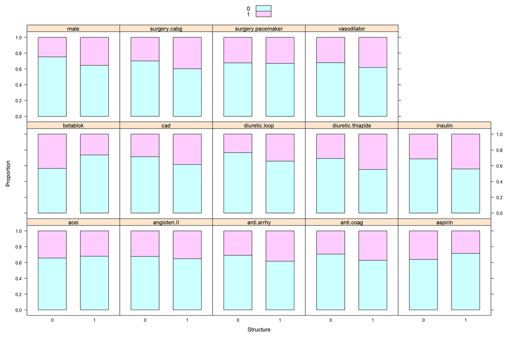

```r
##################################
# Creating a function to formulate
# the proportions table
##################################
EDA.PropTable.Function <- function(FactorVar) {
  EDA.Bar.Source.FactorVar <- EDA.Bar.Source[,c("died",
                                          FactorVar)]
  EDA.Bar.Source.FactorVar.Prop <- as.data.frame(prop.table(table(EDA.Bar.Source.FactorVar), 2))
  names(EDA.Bar.Source.FactorVar.Prop)[2] <- "Structure"
  EDA.Bar.Source.FactorVar.Prop$Variable <- rep(FactorVar,nrow(EDA.Bar.Source.FactorVar.Prop))

  return(EDA.Bar.Source.FactorVar.Prop)

}


EDA.Bar.Source.FactorVar.Prop.Group <- rbind(EDA.PropTable.Function(names(EDA.Bar.Source)[2]),
                                              EDA.PropTable.Function(names(EDA.Bar.Source)[3]),
                                              EDA.PropTable.Function(names(EDA.Bar.Source)[4]),
                                              EDA.PropTable.Function(names(EDA.Bar.Source)[5]),
                                              EDA.PropTable.Function(names(EDA.Bar.Source)[6]),
                                              EDA.PropTable.Function(names(EDA.Bar.Source)[7]),
                                              EDA.PropTable.Function(names(EDA.Bar.Source)[8]),
                                              EDA.PropTable.Function(names(EDA.Bar.Source)[9]),
                                              EDA.PropTable.Function(names(EDA.Bar.Source)[10]),
                                              EDA.PropTable.Function(names(EDA.Bar.Source)[11]),
                                              EDA.PropTable.Function(names(EDA.Bar.Source)[12]),
                                              EDA.PropTable.Function(names(EDA.Bar.Source)[13]),
                                              EDA.PropTable.Function(names(EDA.Bar.Source)[14]),
                                              EDA.PropTable.Function(names(EDA.Bar.Source)[15]))

(EDA.Barchart.FactorVar <- barchart(EDA.Bar.Source.FactorVar.Prop.Group[,3] ~
                                      EDA.Bar.Source.FactorVar.Prop.Group[,2] | EDA.Bar.Source.FactorVar.Prop.Group[,4],
                                      data=EDA.Bar.Source.FactorVar.Prop.Group,
                                      groups = EDA.Bar.Source.FactorVar.Prop.Group[,1],
                                      stack=TRUE,
                                      ylab = "Proportion",
                                      xlab = "Structure",
                                      auto.key = list(adj = 1),
                                      layout=(c(5,3))))
```

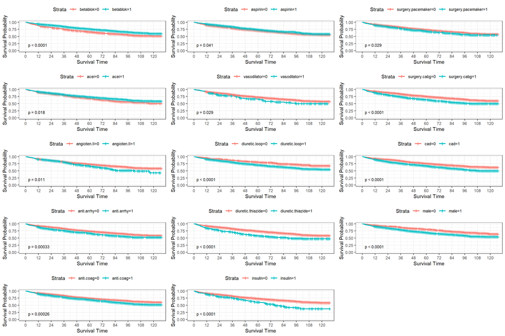

```r
##################################
# Formulating the Kaplan-Meier plots
# for the categorical variables
##################################
KM_PreModelling_Train <- PMA_PreModelling_Train
KM_PreModelling_Train$died <- as.numeric(KM_PreModelling_Train$died )

KM_betablok <- survfit(Surv(ttodead, died) ~ betablok,
                      data=KM_PreModelling_Train)
KMPlot_betablok <- ggsurvplot(KM_betablok,
                            xlab="Survival Time",
                            ylab="Survival Probability",
                            break.time.by=12,
                            ggtheme=theme_bw(),
                            fontsize=3,
                            pval.size=3,
                            pval=TRUE)

KM_aspirin <- survfit(Surv(ttodead, died) ~ aspirin,
                      data=KM_PreModelling_Train)
KMPlot_aspirin <- ggsurvplot(KM_aspirin,
                            xlab="Survival Time",
                            ylab="Survival Probability",
                            break.time.by=12,
                            ggtheme=theme_bw(),
                            fontsize=3,
                            pval.size=3,
                            pval=TRUE)

KM_anti.coag <- survfit(Surv(ttodead, died) ~ anti.coag,
                      data=KM_PreModelling_Train)
KMPlot_anti.coag <- ggsurvplot(KM_anti.coag,
                            xlab="Survival Time",
                            ylab="Survival Probability",
                            break.time.by=12,
                            ggtheme=theme_bw(),
                            fontsize=3,
                            pval.size=3,
                            pval=TRUE)

KM_anti.arrhy <- survfit(Surv(ttodead, died) ~ anti.arrhy,
                      data=KM_PreModelling_Train)
KMPlot_anti.arrhy <- ggsurvplot(KM_anti.arrhy,
                            xlab="Survival Time",
                            ylab="Survival Probability",
                            break.time.by=12,
                            ggtheme=theme_bw(),
                            fontsize=3,
                            pval.size=3,
                            pval=TRUE)

KM_angioten.II <- survfit(Surv(ttodead, died) ~ angioten.II,
                      data=KM_PreModelling_Train)
KMPlot_angioten.II <- ggsurvplot(KM_angioten.II,
                            xlab="Survival Time",
                            ylab="Survival Probability",
                            break.time.by=12,
                            ggtheme=theme_bw(),
                            fontsize=3,
                            pval.size=3,
                            pval=TRUE)

KM_acei <- survfit(Surv(ttodead, died) ~ acei,
                      data=KM_PreModelling_Train)
KMPlot_acei <- ggsurvplot(KM_acei,
                            xlab="Survival Time",
                            ylab="Survival Probability",
                            break.time.by=12,
                            ggtheme=theme_bw(),
                            fontsize=3,
                            pval.size=3,
                            pval=TRUE)

KM_diuretic.thiazide <- survfit(Surv(ttodead, died) ~ diuretic.thiazide,
                      data=KM_PreModelling_Train)
KMPlot_diuretic.thiazide <- ggsurvplot(KM_diuretic.thiazide,
                            xlab="Survival Time",
                            ylab="Survival Probability",
                            break.time.by=12,
                            ggtheme=theme_bw(),
                            fontsize=3,
                            pval.size=3,
                            pval=TRUE)

KM_diuretic.loop <- survfit(Surv(ttodead, died) ~ diuretic.loop,
                      data=KM_PreModelling_Train)
KMPlot_diuretic.loop <- ggsurvplot(KM_diuretic.loop,
                            xlab="Survival Time",
                            ylab="Survival Probability",
                            break.time.by=12,
                            ggtheme=theme_bw(),
                            fontsize=3,
                            pval.size=3,
                            pval=TRUE)

KM_cad <- survfit(Surv(ttodead, died) ~ cad,
                      data=KM_PreModelling_Train)
KMPlot_cad <- ggsurvplot(KM_cad,
                            xlab="Survival Time",
                            ylab="Survival Probability",
                            break.time.by=12,
                            ggtheme=theme_bw(),
                            fontsize=3,
                            pval.size=3,
                            pval=TRUE)

KM_male <- survfit(Surv(ttodead, died) ~ male,
                      data=KM_PreModelling_Train)
KMPlot_male <- ggsurvplot(KM_male,
                            xlab="Survival Time",
                            ylab="Survival Probability",
                            break.time.by=12,
                            ggtheme=theme_bw(),
                            fontsize=3,
                            pval.size=3,
                            pval=TRUE)

KM_insulin <- survfit(Surv(ttodead, died) ~ insulin,
                      data=KM_PreModelling_Train)
KMPlot_insulin <- ggsurvplot(KM_insulin,
                            xlab="Survival Time",
                            ylab="Survival Probability",
                            break.time.by=12,
                            ggtheme=theme_bw(),
                            fontsize=3,
                            pval.size=3,
                            pval=TRUE)

KM_vasodilator <- survfit(Surv(ttodead, died) ~ vasodilator,
                      data=KM_PreModelling_Train)
KMPlot_vasodilator <- ggsurvplot(KM_vasodilator,
                            xlab="Survival Time",
                            ylab="Survival Probability",
                            break.time.by=12,
                            ggtheme=theme_bw(),
                            fontsize=3,
                            pval.size=3,
                            pval=TRUE)

KM_surgery.pacemaker <- survfit(Surv(ttodead, died) ~ surgery.pacemaker,
                      data=KM_PreModelling_Train)
KMPlot_surgery.pacemaker <- ggsurvplot(KM_surgery.pacemaker,
                            xlab="Survival Time",
                            ylab="Survival Probability",
                            break.time.by=12,
                            ggtheme=theme_bw(),
                            fontsize=3,
                            pval.size=3,
                            pval=TRUE)

KM_surgery.cabg <- survfit(Surv(ttodead, died) ~ surgery.cabg,
                      data=KM_PreModelling_Train)
KMPlot_surgery.cabg <- ggsurvplot(KM_surgery.cabg,
                            xlab="Survival Time",
                            ylab="Survival Probability",
                            break.time.by=12,
                            ggtheme=theme_bw(),
                            fontsize=3,
                            pval.size=3,
                            pval=TRUE)

KMPlot_List <- list()
KMPlot_List[[1]] <- KMPlot_betablok
KMPlot_List[[2]] <- KMPlot_acei
KMPlot_List[[3]] <- KMPlot_angioten.II
KMPlot_List[[4]] <- KMPlot_anti.arrhy
KMPlot_List[[5]] <- KMPlot_anti.coag
KMPlot_List[[6]] <- KMPlot_aspirin
KMPlot_List[[7]] <- KMPlot_vasodilator
KMPlot_List[[8]] <- KMPlot_diuretic.loop
KMPlot_List[[9]] <- KMPlot_diuretic.thiazide
KMPlot_List[[10]] <- KMPlot_insulin
KMPlot_List[[11]] <- KMPlot_surgery.pacemaker
KMPlot_List[[12]] <- KMPlot_surgery.cabg
KMPlot_List[[13]] <- KMPlot_cad
KMPlot_List[[14]] <- KMPlot_male

arrange_ggsurvplots(KMPlot_List,
                    ncol=3,
                    nrow=5)
```

## 1.5 Penalized Survival Models

### 1.5.1 Least Absolute Shrinkage and Selection Operator (LASSO)

[Least Absolute Shrinkage and Selection Operator Regression](https://rss.onlinelibrary.wiley.com/doi/abs/10.1111/j.2517-6161.1996.tb02080.x) is a regression technique aimed at preventing overfitting when the model is too complex and fits the training data very closely, but performs poorly on new and unseen data. The algorithm adds a penalty term (referred to as the L1 regularization) to the regression cost function that is proportional to the absolute value of the coefficients. This approach can be useful for feature selection, as it tends to shrink the coefficients of less important predictor variables to zero, which can help simplify the model and improve its interpretability. A hyperparameter fraction that controls the ratio of the L1 norm of the coefficient vector relative to the norm at the full solution needs to be optimized through cross-validation.

**Code Chunk | Output**

```r
##################################
# Loading the preprocessed data
##################################
PMA_PreModelling_LASSO <- peakVO2.Source[,!names(peakVO2.Source) %in% rownames(UF_CoxPHModelSummary_NonSig)]

##################################
# Setting the appropriate variable types
##################################
PMA_PreModelling_LASSO$died <- as.factor(PMA_PreModelling_LASSO$died)

##################################
# Creating a local object
# for the train and test sets
##################################
set.seed(88888888)
TrainIndex <- createDataPartition(PMA_PreModelling_LASSO$died,
                                  p = 0.8,
                                  list = FALSE,
                                  times = 1)

PMA_PreModelling_LASSO_Train <- PMA_PreModelling_LASSO[ TrainIndex,]
PMA_PreModelling_LASSO_Test  <- PMA_PreModelling_LASSO[-TrainIndex,]

PMA_PreModelling_LASSO_Train$died <- as.numeric(PMA_PreModelling_LASSO_Train$died)
PMA_PreModelling_LASSO_Test$died  <- as.numeric(PMA_PreModelling_LASSO_Test$died)

##################################
# Formulating the model components
# for the train data
##################################
LASSO_Train_Predictors <- as.matrix(
  PMA_PreModelling_LASSO_Train[,!names(PMA_PreModelling_LASSO_Train)
                               %in% c("ttodead","died")])
LASSO_Train_Time    <- PMA_PreModelling_LASSO_Train$ttodead
LASSO_Train_Status  <- PMA_PreModelling_LASSO_Train$died
LASSO_Train_Response <- survival::Surv(LASSO_Train_Time, LASSO_Train_Status)

##################################
# Fitting a LASSO model
##################################
LASSO_Train_CoxPH_Fit <- fit_lasso(LASSO_Train_Predictors,
                              LASSO_Train_Response,
                              nfolds = 5,
                              rule = "lambda.1se",
                              seed = 88888888)

##################################
# Extracting the model objects and
# optimal hyperparameters
# from the LASSO model
##################################
(LASSO_Train_CoxPH_Model  <- LASSO_Train_CoxPH_Fit$model)
```

```
##
## Call:  glmnet(x = x, y = y, family = "cox", alpha = 1, lambda = lambda_opt)
##
##   Df %Dev  Lambda
## 1  5 3.53 0.06069
```

```r
(LASSO_Train_CoxPH_Model  <- LASSO_Train_CoxPH_Fit$model$beta)
```

```
## 25 x 1 sparse Matrix of class "dgCMatrix"
##                                s0
## age                  .
## betablok            -0.0377520101
## acei                 .
## angioten.II          .
## anti.arrhy           .
## anti.coag            .
## aspirin              .
## vasodilator          .
## diuretic.loop        .
## diuretic.thiazide    .
## insulin              .
## surgery.pacemaker    .
## surgery.cabg         .
## resting.systolic.bp  .
## resting.hr           .
## lvef.metabl          .
## peak.vo2            -0.0368006806
## interval            -0.0006522149
## cad                  .
## bun                  0.0136907025
## sodium               .
## hgb                  .
## glucose              .
## male                 0.0325561008
## crcl                 .
```

```r
(LASSO_Train_CoxPH_Alpha  <- LASSO_Train_CoxPH_Fit$alpha)
```

```r
(LASSO_Train_CoxPH_Lambda <- LASSO_Train_CoxPH_Fit$lambda)
```

```
## [1] 0.06068989
```

```r
(LASSO_Train_CoxPH_PenaltyFactor <- LASSO_Train_CoxPH_Fit$pen_factor)
```

```r
##################################
# Conducting an internal validation
# of the LASSO model
# using a 50-cycle bootstrap
##################################
LASSO_Train_CoxPH_Model_InternalValidation <- validate(LASSO_Train_Predictors,
                                                       LASSO_Train_Time,
                                                       LASSO_Train_Status,
                                                       model.type = "lasso",
                                                       alpha = 1,
                                                       lambda = LASSO_Train_CoxPH_Fit$lambda,
                                                       method = "bootstrap",
                                                       boot.times = 50,
                                                       tauc.type = "UNO",
                                                       tauc.time = seq(12, 120, 12),
                                                       seed = 88888888)
```

[output not shown]

```r
print(LASSO_Train_CoxPH_Model_InternalValidation)
```

```
## High-Dimensional Cox Model Validation Object
## Random seed: 88888888
## Validation method: bootstrap
## Bootstrap samples: 50
## Model type: lasso
## glmnet model alpha: 1
## glmnet model lambda: 0.06068989
## glmnet model penalty factor: not specified
## Time-dependent AUC type: UNO
## Evaluation time points for tAUC: 12 24 36 48 60 72 84 96 108 120
```

```r
summary(LASSO_Train_CoxPH_Model_InternalValidation)
```

```
## Time-Dependent AUC Summary at Evaluation Time Points
##                 12        24        36        48        60        72        84
## Mean     0.7591606 0.7651505 0.6598180 0.6668614 0.6573271 0.6717549 0.7167163
## Min      0.7468533 0.7528590 0.6375564 0.6564413 0.6428270 0.6515716 0.6950791
## 0.25 Qt. 0.7556877 0.7619354 0.6532144 0.6632977 0.6524156 0.6662698 0.7111428
## Median   0.7593593 0.7646676 0.6581791 0.6661259 0.6567368 0.6713395 0.7160384
## 0.75 Qt. 0.7622169 0.7691297 0.6652583 0.6695167 0.6626247 0.6769218 0.7239472
## Max      0.7693340 0.7782079 0.6837068 0.6789755 0.6707026 0.6948704 0.7344319
##                 96       108       120
## Mean     0.5969193 0.6653184 0.5362073
## Min      0.5663553 0.5794224 0.2889561
## 0.25 Qt. 0.5832283 0.6466446 0.4818164
## Median   0.5971917 0.6706664 0.5622711
## 0.75 Qt. 0.6065677 0.6875236 0.5988114
## Max      0.6471559 0.7249818 0.7560349
```

```r
LASSO_Train_IV_Summary <- data.frame(matrix(ncol=3, nrow=8))
names(LASSO_Train_IV_Summary) <- c("Algorithm","Validation","MedianAUROC")

for (i in 1:8){
  LASSO_Train_IV_Summary[i,1] <- "LASSO"
  LASSO_Train_IV_Summary[i,2] <- "Cross-Validation"
  LASSO_Train_IV_Summary[i,3] <- summary(LASSO_Train_CoxPH_Model_InternalValidation)[[4,i]]
}
```

[output not shown]

[output cut: 65 more lines]

```
## Time-Dependent AUC Summary at Evaluation Time Points
##                 12        24        36        48        60        72        84
## Mean     0.7591606 0.7651505 0.6598180 0.6668614 0.6573271 0.6717549 0.7167163
## Min      0.7468533 0.7528590 0.6375564 0.6564413 0.6428270 0.6515716 0.6950791
## 0.25 Qt. 0.7556877 0.7619354 0.6532144 0.6632977 0.6524156 0.6662698 0.7111428
## Median   0.7593593 0.7646676 0.6581791 0.6661259 0.6567368 0.6713395 0.7160384
## 0.75 Qt. 0.7622169 0.7691297 0.6652583 0.6695167 0.6626247 0.6769218 0.7239472
## Max      0.7693340 0.7782079 0.6837068 0.6789755 0.6707026 0.6948704 0.7344319
##                 96       108       120
## Mean     0.5969193 0.6653184 0.5362073
## Min      0.5663553 0.5794224 0.2889561
## 0.25 Qt. 0.5832283 0.6466446 0.4818164
## Median   0.5971917 0.6706664 0.5622711
## 0.75 Qt. 0.6065677 0.6875236 0.5988114
## Max      0.6471559 0.7249818 0.7560349
```

```r
LASSO_Train_IV_Summary
```

```
##   Algorithm       Validation MedianAUROC
## 1     LASSO Cross-Validation   0.7593593
## 2     LASSO Cross-Validation   0.7646676
## 3     LASSO Cross-Validation   0.6581791
## 4     LASSO Cross-Validation   0.6661259
## 5     LASSO Cross-Validation   0.6567368
## 6     LASSO Cross-Validation   0.6713395
## 7     LASSO Cross-Validation   0.7160384
## 8     LASSO Cross-Validation   0.5971917
```

```
##                 12        24        36        48        60        72        84
## Mean     0.7591606 0.7651505 0.6598180 0.6668614 0.6573271 0.6717549 0.7167163
## Min      0.7468533 0.7528590 0.6375564 0.6564413 0.6428270 0.6515716 0.6950791
## 0.25 Qt. 0.7556877 0.7619354 0.6532144 0.6632977 0.6524156 0.6662698 0.7111428
## Median   0.7593593 0.7646676 0.6581791 0.6661259 0.6567368 0.6713395 0.7160384
## 0.75 Qt. 0.7622169 0.7691297 0.6652583 0.6695167 0.6626247 0.6769218 0.7239472
## Max      0.7693340 0.7782079 0.6837068 0.6789755 0.6707026 0.6948704 0.7344319
##                 96       108       120
## Mean     0.5969193 0.6653184 0.5362073
## Min      0.5663553 0.5794224 0.2889561
## 0.25 Qt. 0.5832283 0.6466446 0.4818164
## Median   0.5971917 0.6706664 0.5622711
## 0.75 Qt. 0.6065677 0.6875236 0.5988114
## Max      0.6471559 0.7249818 0.7560349
```

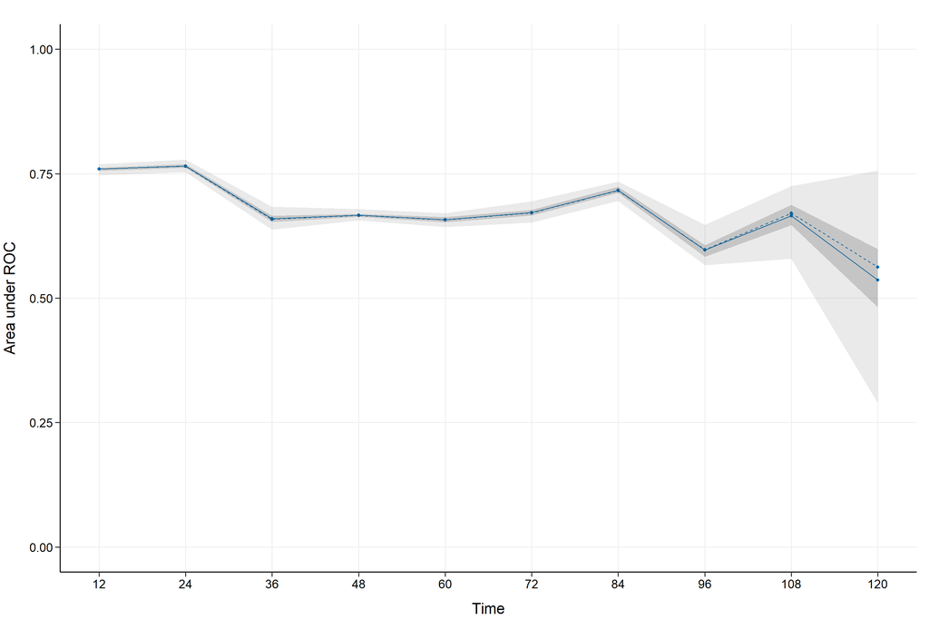

```r
plot(LASSO_Train_CoxPH_Model_InternalValidation,
     ylim = c(0, 1))
```

```r
##################################
# Conducting an external validation
# of the LASSO model
# using the test data
##################################
LASSO_Test_Predictors <- as.matrix(
  PMA_PreModelling_LASSO_Test[,!names(PMA_PreModelling_LASSO_Test)
                               %in% c("ttodead","died")])
LASSO_Test_Time    <- PMA_PreModelling_LASSO_Test$ttodead
LASSO_Test_Status  <- PMA_PreModelling_LASSO_Test$died
LASSO_Test_Response <- survival::Surv(LASSO_Test_Time, LASSO_Test_Status)

LASSO_Train_CoxPH_Model_ExternalValidation <- validate_external(LASSO_Train_CoxPH_Fit,
                                                       LASSO_Train_Predictors,
                                                       LASSO_Train_Time,
                                                       LASSO_Train_Status,
                                                       LASSO_Test_Predictors,
                                                       LASSO_Test_Time,
                                                       LASSO_Test_Status,
                                                       tauc.type = "UNO",
                                                       tauc.time = seq(12, 120, 12))

print(LASSO_Train_CoxPH_Model_ExternalValidation)
```

```
## High-Dimensional Cox Model External Validation Object
## Model type: lasso
## Time-dependent AUC type: UNO
## Evaluation time points for tAUC: 12 24 36 48 60 72 84 96 108 120
```

```r
summary(LASSO_Train_CoxPH_Model_ExternalValidation)
```

```
## Time-Dependent AUC Summary at Evaluation Time Points
##            12        24        36        48        60        72        84
## AUC 0.7552909 0.7416851 0.6366259 0.6214336 0.6549471 0.6722079 0.6516368
##            96       108   120
## AUC 0.7317083 0.3407045 0.325
```

```r
LASSO_Train_EV_Summary <- data.frame(matrix(ncol=3, nrow=8))
names(LASSO_Train_EV_Summary) <- c("Algorithm","Validation","MedianAUROC")

for (i in 1:8){
  LASSO_Train_EV_Summary[i,1] <- "LASSO"
  LASSO_Train_EV_Summary[i,2] <- "Test"
  LASSO_Train_EV_Summary[i,3] <- summary(LASSO_Train_CoxPH_Model_ExternalValidation)[[1,i]]
}
```

[output not shown]

```r
LASSO_Train_EV_Summary
```

```
##   Algorithm Validation MedianAUROC
## 1     LASSO       Test   0.7552909
## 2     LASSO       Test   0.7416851
## 3     LASSO       Test   0.6366259
## 4     LASSO       Test   0.6214336
## 5     LASSO       Test   0.6549471
## 6     LASSO       Test   0.6722079
## 7     LASSO       Test   0.6516368
## 8     LASSO       Test   0.7317083
```

```
##            12        24        36        48        60        72        84
## AUC 0.7552909 0.7416851 0.6366259 0.6214336 0.6549471 0.6722079 0.6516368
##            96       108   120
## AUC 0.7317083 0.3407045 0.325
```

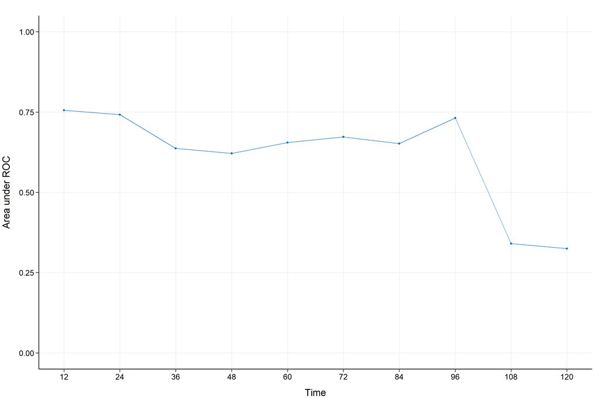

```r
plot(LASSO_Train_CoxPH_Model_ExternalValidation,
     ylim = c(0, 1))
```

```r
##################################
# Conducting an internal calibration
# of the LASSO model
# using a 50-cycle bootstrap
# for Year 5
##################################
LASSO_Train_CoxPH_Model_InternalCalibration <- calibrate(LASSO_Train_Predictors,
                                                       LASSO_Train_Time,
                                                       LASSO_Train_Status,
                                                       model.type = "lasso",
                                                       alpha = 1,
                                                       lambda = LASSO_Train_CoxPH_Fit$lambda,
                                                       method = "bootstrap",
                                                       boot.times = 50,
                                                       pred.at = 60,
                                                       ngroup = 3,
                                                       seed = 88888888)
```

[output not shown]

```r
print(LASSO_Train_CoxPH_Model_InternalCalibration)
```

```
## High-Dimensional Cox Model Calibration Object
## Random seed: 88888888
## Calibration method: bootstrap
## Bootstrap samples: 50
## Model type: lasso
## glmnet model alpha: 1
## glmnet model lambda: 0.06068989
## glmnet model penalty factor: not specified
## Calibration time point: 60
## Number of groups formed for calibration: 3
```

```r
summary(LASSO_Train_CoxPH_Model_InternalCalibration)
```

```
##   Calibration Summary Table
##   Predicted  Observed Lower 95% Upper 95%
## 1 0.6332843 0.5270044 0.4853813 0.5721969
## 2 0.7269382 0.7714103 0.7359916 0.8085336
## 3 0.8083382 0.8713612 0.8430459 0.9006276
```

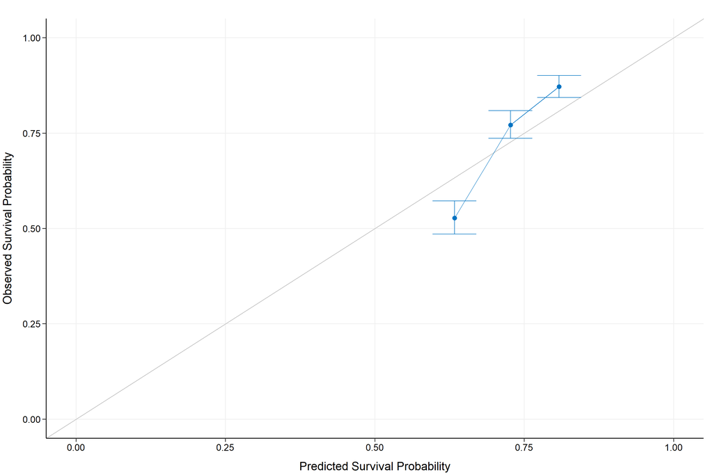

```r
plot(LASSO_Train_CoxPH_Model_InternalCalibration)
```

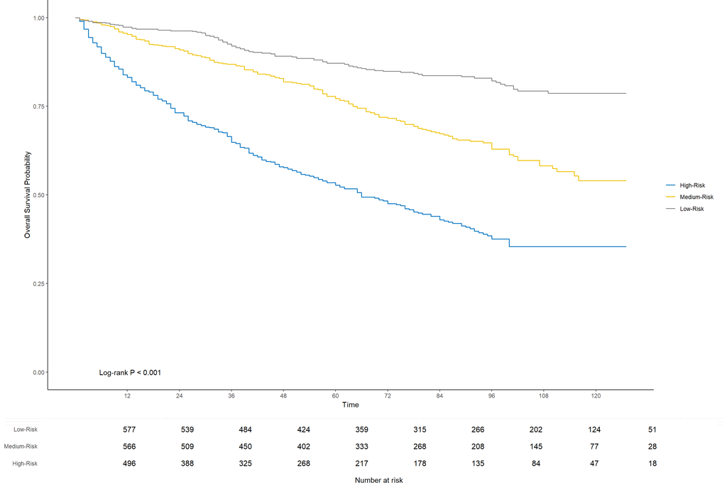

```r
##################################
# Estimating survival curves
# of the LASSO model
# for the risk groups
# using the train data
##################################
LASSO_Train_CoxPH_Model_KMPlot <- kmplot( LASSO_Train_CoxPH_Model_InternalCalibration,
                                          group.name = c("High-Risk", "Medium-Risk", "Low-Risk"),
                                          time.at = 1:10 * 12)
```

```r
##################################
# Conducting an internal calibration
# of the LASSO model
# using a 50-cycle bootstrap
# for Year 10
##################################
LASSO_Train_CoxPH_Model_InternalCalibration <- calibrate(LASSO_Train_Predictors,
                                                       LASSO_Train_Time,
                                                       LASSO_Train_Status,
                                                       model.type = "lasso",
                                                       alpha = 1,
                                                       lambda = LASSO_Train_CoxPH_Fit$lambda,
                                                       method = "bootstrap",
                                                       boot.times = 50,
                                                       pred.at = 120,
                                                       ngroup = 3,
                                                       seed = 88888888)
```

[output not shown]

```r
print(LASSO_Train_CoxPH_Model_InternalCalibration)
```

```
## High-Dimensional Cox Model Calibration Object
## Random seed: 88888888
## Calibration method: bootstrap
## Bootstrap samples: 50
## Model type: lasso
## glmnet model alpha: 1
## glmnet model lambda: 0.06068989
## glmnet model penalty factor: not specified
## Calibration time point: 120
## Number of groups formed for calibration: 3
```

```r
summary(LASSO_Train_CoxPH_Model_InternalCalibration)
```

```
##   Calibration Summary Table
##   Predicted  Observed Lower 95% Upper 95%
## 1 0.4348425 0.3537721 0.3071830 0.4074271
## 2 0.5590328 0.5403953 0.4792945 0.6092852
## 3 0.6784640 0.7864948 0.7447209 0.8306119
```

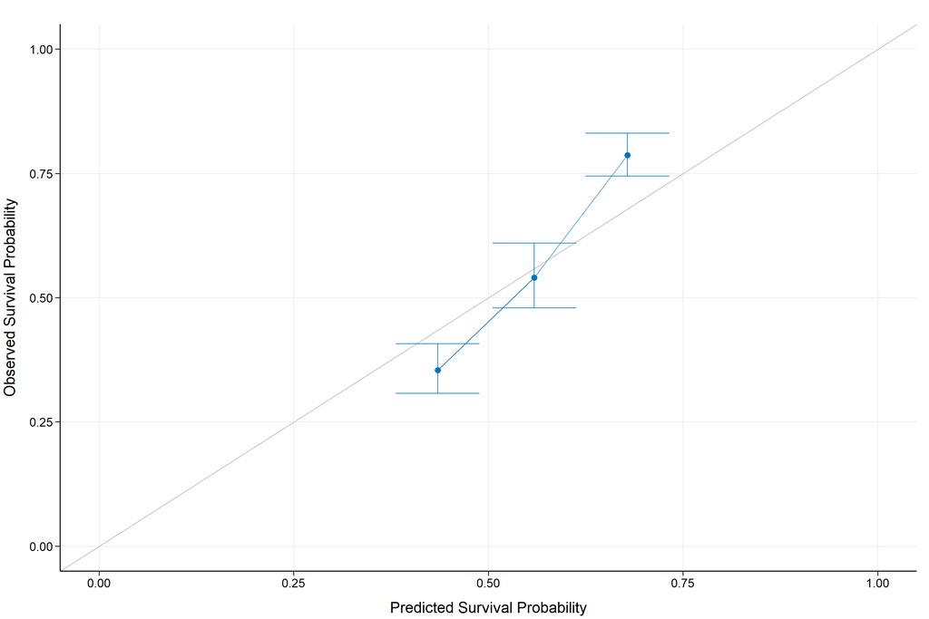

```r
plot(LASSO_Train_CoxPH_Model_InternalCalibration)
```

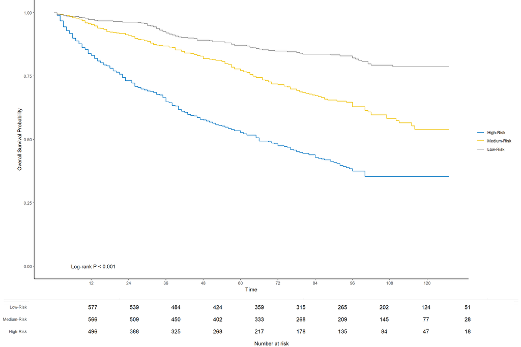

```r
##################################
# Estimating survival curves
# of the LASSO model
# for the risk groups
# using the train data
##################################
LASSO_Train_CoxPH_Model_KMPlot <- kmplot( LASSO_Train_CoxPH_Model_InternalCalibration,
                                          group.name = c("High-Risk", "Medium-Risk", "Low-Risk"),
                                          time.at = 1:10 * 12)
```

```r
##################################
# Conducting an external calibration
# of the LASSO model
# using the test data
# for Year 5
##################################
LASSO_Train_CoxPH_Model_ExternalCalibration <- calibrate_external(LASSO_Train_CoxPH_Fit,
                                                       LASSO_Train_Predictors,
                                                       LASSO_Train_Time,
                                                       LASSO_Train_Status,
                                                       LASSO_Test_Predictors,
                                                       LASSO_Test_Time,
                                                       LASSO_Test_Status,
                                                       pred.at = 60,
                                                       ngroup = 3)

print(LASSO_Train_CoxPH_Model_ExternalCalibration)
```

```
## High-Dimensional Cox Model External Calibration Object
## Model type: lasso
## Calibration time point: 60
## Number of groups formed for calibration: 3
```

```r
summary(LASSO_Train_CoxPH_Model_ExternalCalibration)
```

```
##   External Calibration Summary Table
##   Predicted  Observed Lower 95% Upper 95%
## 1 0.6255384 0.5581767 0.4789768 0.6504725
## 2 0.7299284 0.6789203 0.6031764 0.7641758
## 3 0.8074499 0.8808991 0.8275443 0.9376940
```

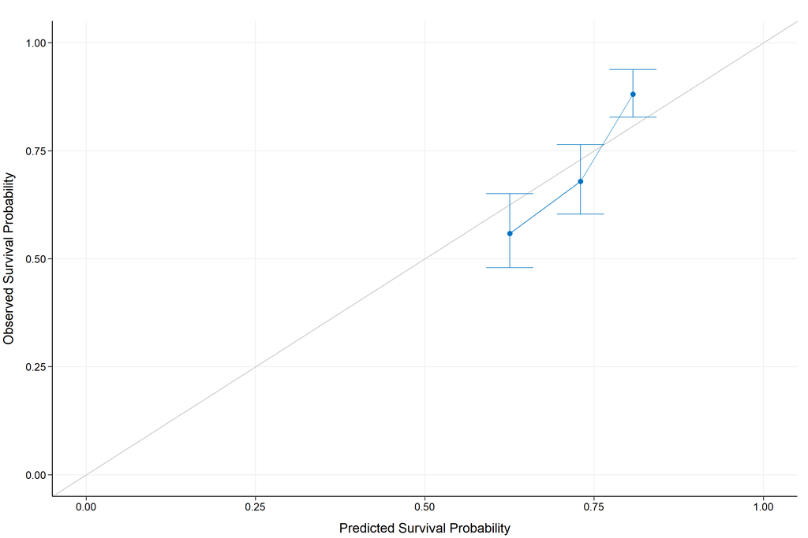

```r
plot(LASSO_Train_CoxPH_Model_ExternalCalibration)
```

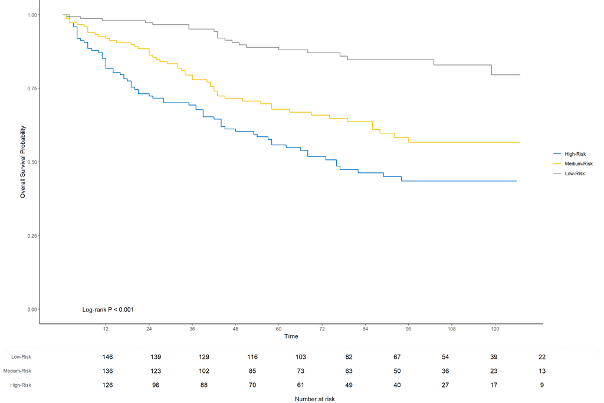

```r
##################################
# Estimating survival curves
# of the LASSO model
# for the risk groups
# using the test data
##################################
LASSO_Test_CoxPH_Model_KMPlot <- kmplot( LASSO_Train_CoxPH_Model_ExternalCalibration,
                                          group.name = c("High-Risk", "Medium-Risk", "Low-Risk"),
                                          time.at = 1:10 * 12)
```

```r
##################################
# Conducting an external calibration
# of the LASSO model
# using the test data
# for Year 10
##################################
LASSO_Train_CoxPH_Model_ExternalCalibration <- calibrate_external(LASSO_Train_CoxPH_Fit,
                                                       LASSO_Train_Predictors,
                                                       LASSO_Train_Time,
                                                       LASSO_Train_Status,
                                                       LASSO_Test_Predictors,
                                                       LASSO_Test_Time,
                                                       LASSO_Test_Status,
                                                       pred.at = 120,
                                                       ngroup = 3)

print(LASSO_Train_CoxPH_Model_ExternalCalibration)
```

```
## High-Dimensional Cox Model External Calibration Object
## Model type: lasso
## Calibration time point: 120
## Number of groups formed for calibration: 3
```

```r
summary(LASSO_Train_CoxPH_Model_ExternalCalibration)
```

```
##   External Calibration Summary Table
##   Predicted  Observed Lower 95% Upper 95%
## 1 0.4193310 0.4355568 0.3516847 0.5394313
## 2 0.5581158 0.5668081 0.4787103 0.6711187
## 3 0.6728682 0.7962081 0.7073103 0.8962789
```

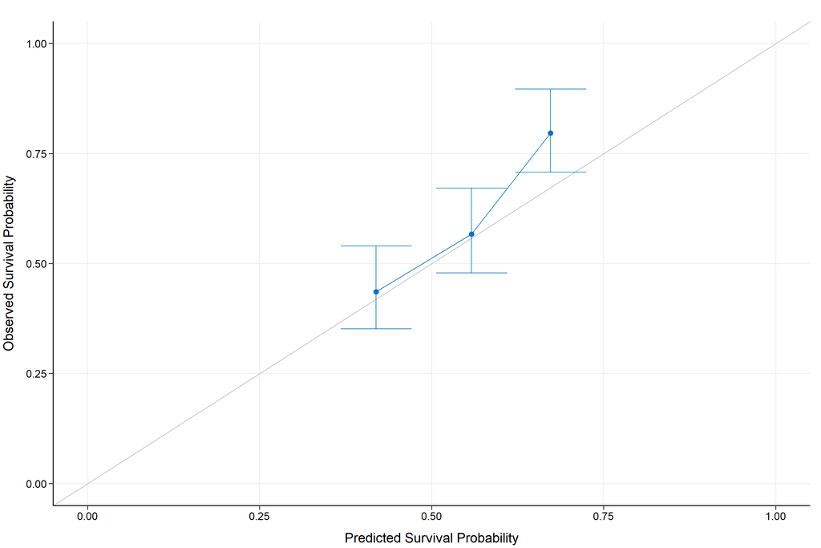

```r
plot(LASSO_Train_CoxPH_Model_ExternalCalibration)
```

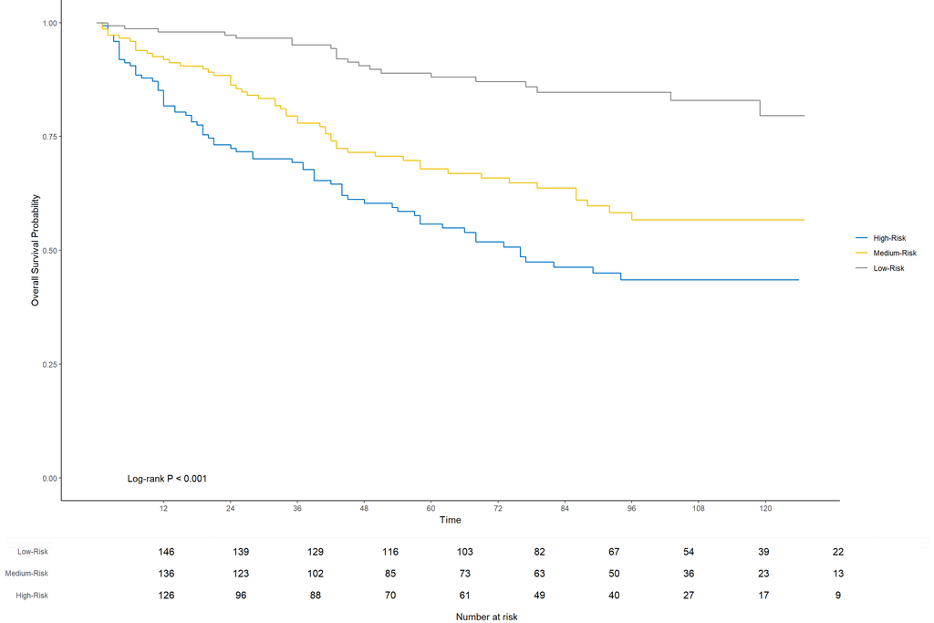

```r
##################################
# Estimating survival curves
# of the LASSO model
# for the risk groups
# using the test data
##################################
LASSO_Test_CoxPH_Model_KMPlot <- kmplot( LASSO_Train_CoxPH_Model_ExternalCalibration,
                                          group.name = c("High-Risk", "Medium-Risk", "Low-Risk"),
                                          time.at = 1:10 * 12)
```